- View **PDF**

## [Clinical Psychology Review](https://www.sciencedirect.com/journal/clinical-psychology-review)

[Volume 31, Issue 3](https://www.sciencedirect.com/journal/clinical-psychology-review/vol/31/issue/3), April 2011, Pages 449-464

# Does mindfulness training improve cognitive abilities? A systematic review of neuropsychological findings

https://doi.org/10.1016/j.cpr.2010.11.003[Get rights and content](https://s100.copyright.com/AppDispatchServlet?publisherName=ELS&contentID=S027273581000173X&orderBeanReset=true)

Full text access

Abstract

Mindfulness meditation practices (MMPs) are a subgroup of meditation practices which are receiving growing attention. The present paper reviews current evidence about the effects of MMPs on objective measures of cognitive functions. Five databases were searched. Twenty three studies providing measures of attention, memory, executive functions and further miscellaneous measures of cognition were included. Fifteen were controlled or randomized controlled studies and 8 were case–control studies. Overall, reviewed studies suggested that early phases of mindfulness training, which are more concerned with the development of focused attention, could be associated with significant improvements in selective and executive attention whereas the following phases, which are characterized by an open monitoring of internal and external stimuli, could be mainly associated with improved unfocused sustained attention abilities. Additionally, MMPs could enhance working memory capacity and some executive functions. However, many of the included studies show methodological limitations and negative results have been reported as well, plausibly reflecting differences in study design, study duration and patients' populations. Accordingly, even though findings here reviewed provided preliminary evidence suggesting that MMPs could enhance cognitive functions, available evidence should be considered with caution and further high quality studies investigating more standardized mindfulness meditation programs are needed.

### Research Highlights

► Mindfulness training could enhance several domains of attention. ► Mindfulness training could enhance some domains of memory and executive functions. ► Each specific subcomponent of mindfulness training has different effects on cognition. ► Methodological and theoretical issues limit the interpretation of current evidence. ► Further research is needed to explore more standardized mindfulness trainings.

- [Previous article in issue](https://www.sciencedirect.com/science/article/pii/S0272735810001716)
- [Next article in issue](https://www.sciencedirect.com/science/article/pii/S0272735810001753)

## Keywords

Mindfulness

Meditation

MBSR

MBCT

Attention

Memory

## 1. Introduction

Mindfulness meditation practices (MMPs) are a subgroup of meditation practices which are receiving growing attention (Chiesa and Serretti, 2010, Ivanovski and Malhi, 2007). The word “mindfulness”, currently used to describe a particular way of paying attention to the present moment characterized by a receptive and non-judgemental attitude (Kabat-Zinn, 1994), derives from the Pāli word *sati* which can be originally found in the Abhidamma (Kiyota, 1978) and later in the Vishuddimagga (Buddhaghosa, 1976), a summary of the part of the Abhidamma that deals with meditation. Indeed, such term is frequently used to describe a particular type of meditation practices characterized by an open monitoring of present moment experiences which are usually separated and considered as a possible development of concentrative or “focused attention” meditations (Lutz, Slagter, Dunne, & Davidson, 2008).

The concept of mindfulness has its roots in Buddhist philosophy and MMP is a key element of several Buddhist meditations including Vipassana (Gunaratana, 1993) and Zen meditations (Kapleau, 1965). In the last decades mindfulness training has been widely incorporated into several clinically oriented group based meditation programs such as Mindfulness Based Stress Reduction (MBSR) (Kabat-Zinn, 1990) and Mindfulness Based Cognitive Therapy (MBCT) (Segal, Williams, & Teasdale, 2002). In addition, a number of psychological interventions including, among others, Dialectical Behavior Therapy (DBT) (Linehan, 1993) and Acceptance and Commitment Therapy (ACT) (Hayes, Strosahl, & Wilson, 1999), are usually considered as consistent with current conceptualizations of mindfulness and included among modern mindfulness based interventions (Baer, 2003). Note, however, that such interventions only partially incorporate formal meditation training and are characterized by significant differences as compared with other MMPs (Chiesa and Malinowski, submitted for publication, Rapgay and Bystrisky, 2009).

Of note, current evidence suggests that mindfulness training could have significant benefit on health, including reduced alcohol and substance consumption (Bowen et al., 2006), reduced blood pressure (Chiesa, 2009), decreased anxiety, depressive symptoms and relapses (Coelho et al., 2007, Kim et al., 2009) as well as significant benefits for patients suffering from various types of chronic pain (Chiesa & Serretti, in press), stress problems (Chiesa & Serretti, 2009), cancer (Ledesma & Kumano, 2009) and several further medical disorders (Chiesa & Serretti, 2010). Even though many studies on MMPs have been criticized for the lack of scientific rigor, including the lack of high quality randomized controlled studies designed to differentiate between the specific (i.e. specifically related to repeated sitting meditation practice) and the non specific (i.e. related to benefits' expectations) effects of such practices (Chiesa and Serretti, 2010, Toneatto and Nguyen, 2007) and the frequent use of self report instruments as measures of clinical improvements following mindfulness training (e.g. Chambers et al., 2009, Ivanovski and Malhi, 2007), overall available studies provide preliminary evidence for the clinical usefulness of such interventions.

It is noteworthy, however, that the bulk of studies investigating the clinical benefits of MMPs stands in stark contrast with the paucity of studies aimed at investigating more objective correlates of such practices, such as their effects on attention and other cognitive functions, at least up to recent years. On the other hand, as recent conceptualizations of MMPs consistently claim that they improve self regulation of attention (e.g. Bishop, Lau, & Shapiro, 2004; K. W. Brown and Ryan, 2003, Lau et al., 2006), the paucity of scientific studies investigating such issue is somewhat surprising and points out the need of a more thorough investigation and review of the cognitive correlates of mindfulness training. In addition, mindfulness meditation masters and instructors have frequently pointed to the benefits that MMPs could have on cognitive abilities, including attention, memory and other cognitive functions (e.g. Gunaratana, 1993, Kapleau, 1965, Teasdale et al., 1995), and such measures could provide empirical evidence concerning possible enhanced cognitive abilities associated with mindfulness training. Note also that significant psychological benefits linked to mindfulness training, including, among others, reduced cognitive reactivity (Raes, Dewulf, Van Heeringen, & Williams, 2009) as well as decreased avoidance and rumination (Kumar, Feldman, & C., H. S., 2008), could depend, at least initially, on the development of attentional control and inhibition of unnecessary elaborative processing (Baer, 2003, Bishop et al., 2004).

Accordingly, the aim of this paper is to review current evidence about the effects of MMPs on objective measures of cognitive functions, defined here in their broadest terms so as to include processes such as attention, memory and executive functions, and to provide a preliminary theoretical integration of reviewed findings. Critical issues concerning differences in the definition of mindfulness and current conceptualizations of cognition are explored, followed by a systematic description of the effects of MMPs on different domains of cognitive functions.

### 1.1. Critical issues related to the construct of mindfulness

The state of mindfulness has frequently been described as a state of “presence of mind” which concerns a clear awareness of one's inner and outer worlds, including thoughts, sensations, emotions, actions or surroundings as they exist at any given moment (Gunaratana, 1993, Kapleau, 1965, Rahula, 1974). Accordingly, it has often been termed as “bare” attention (Gunaratana, 1993, Nyaniponika, 1973, Rahula, 1974), or alternatively as “pure” or “lucid” awareness (Das, 1997, Sogyal, 1992), emphasizing that mindfulness is supposed to reveal what is occurring, before or beyond conceptual and emotional classifications about what is or has taken place.

Unfortunately classical descriptions of mindfulness are usually somewhat poetic and abstract and they do not easily lend themselves to a scientific operationalization that could be used for scientific purposes on this topic. As a consequence, several authors have recently attempted to provide psychologically oriented definitions of mindfulness designed to overcome the difficulties related to early conceptualizations, emphasizing at least two points. The first component of mindfulness is usually referred to as a mental state characterized by full attention to internal and external experiences as they occur in the present moment (Bishop et al., 2004; K. W. Brown and Ryan, 2003, Kabat-Zinn, 1994). The second component is usually described as a particular attitude characterized by non judgment of, and openness to, current experience (Bishop et al., 2004; K. W. Brown and Ryan, 2003, Kabat-Zinn, 1994), which is supposed to lead to higher levels of exposure to negative stimuli and emotions (Kabat-Zinn et al., 1992) as well as to higher acceptance (Brown and Ryan, 2004, Hayes, 1994) and concurrent reduction of experiential avoidance (Hayes et al., 2004). Note, however, that significant discrepancies exist so far across current operational definitions of mindfulness (Baer et al., 2004, Baer et al., 2006; K. W. Brown & Ryan, 2003; A. M. Hayes and Feldman, 2004, Lau et al., 2006, Roemer and Orsillo, 2003).

In addition, it is noteworthy that several differences exist across different MMPs in terms of daily and total length of practice, types of meditation encompassed under the mindfulness “umbrella term” and specific instructions as to how the mindfulness state should be developed and maintained (for a comprehensive review see Lutz, Dunne, & Davidson, 2008). In sum, MMPs are currently delivered both as clinically oriented group based meditation programs, such as MBSR and MBCT, where mindfulness skills are usually taught over a period of 8 weeks and practitioners are asked to meditate for about 45 min daily (Kabat-Zinn, 1990, Segal et al., 2002), and as intensive retreats, where mindfulness techniques are practiced for 10 h or more daily (Forte et al., 1987–1988). Furthermore, the effects of mindfulness training have sometimes been explored as brief (e.g. 10 min) mindfulness-induction interventions (e.g. Erisman & Roemer, 2010). Although it has been pointed out that such interventions should be better labeled as brief “acceptance-based processing” (or with other labels that take into account the specific subcomponents of mindfulness treatments under investigation in each study) rather than “mindfulness training”, such brief laboratory manipulations have been considered as an important aspect of understanding how the cognitive system incorporates new information or procedures and what effects such change has (Williams, 2010).

Note also that in other cases mindfulness is operationalized as a dispositional mental trait (e.g. Brown & Ryan, 2003) which could have arisen through a complex interaction of genetic predisposition, environmental circumstances, and explicit training (Davidson, 2010) and which levels can vary both among different and within single individuals at different time points. It should be pointed out, however, that such different levels of dispositional mindfulness cannot be properly or easily attributed to specific mental training and they are thus systematically excluded from the present review. Nor this review addresses Langer's cognitive model of mindfulness (Langer, 1989, Langer, 1997), which includes alertness to distinctions, context, and multiple perspectives, openness to novelty, and orientation in the present (Sternberg, 2000), and usually involves working with material external to the participants, such as information to be learned or manipulated. Nevertheless, such mindfulness training, as Langer herself have explained (Langer, 1989), should be distinguished from other types of MMPs.

In addition to the issues outlined above, it is noteworthy that mindfulness (often referred to as open monitoring as well) training is usually associated with concentrative (or focused attention) training, such that in early stages of practice the monitoring faculty is needed to detect when mind wanders from the object onto which focused attention is directed, whereas in most advanced stages the practitioner gradually reduces the focus on an explicit object and the monitoring faculty is concurrently emphasized (Lutz et al., 2008, Lutz et al., 2008). Of further concern is the notion that, while in some cases the open monitoring faculty is seen as the final aim as well as the essence of practice, in other cases the open monitoring faculty becomes the basis that subsumes the development of a “reflexive awareness” as a means to understand the moment to moment flow of adaptive and maladaptive thoughts and feelings as well as their triggers and consequences (Lutz et al., 2008, Lutz et al., 2008, Rapgay and Bystrisky, 2009). Accordingly, in order to avoid discrepancies due to systematic differences in the underlying meditation practices, the present review is specifically concerned with cognitive substrates of mindfulness/open monitoring faculty either as a standalone intervention or as a development of prior focused attention meditation training.

### 1.2. Current classifications of cognition

Similar to the definition of mindfulness, there is no clear consensus as to how cognition and its constituents should be properly classified and categorized. Although an exhaustive overview of cognitive functions is out of the aims and possibilities of the present work, this section is aimed at exploring some of the main cognitive functions in order to provide a simplified theoretical framework that underpins our presentation of available findings about MMPs. In particular, we focused on attention, memory, and executive functions since they are the most represented ones in the studies included in this review.

Numerous theories have attempted to identify subcomponents of attention. One of the most consistent theoretical frameworks of attention suggests that it consists of three functionally distinct neural networks: alerting (also referred to as sustained attention or vigilance), orienting (or selective attention or concentration) and executive attention (or divided attention or conflict monitoring) (McDowd, 2007, Posner and Petersen, 1990, Posner and Rothbart, 2007). According to this model, alerting consists of achieving and maintaining a vigilant or alert state of preparedness, orienting regulates and limits attention to a subset of possible sensorial inputs, and executive attention prioritizes among competing thoughts, feelings, and responses (Posner, 2008, Posner and Petersen, 1990, Posner and Rothbart, 2007). In addition to these subsets of attention, the model suggested by Mirsky, Anthony, Duncan, Ahearn, and Kellam (1991) also includes shift of attention/attention switching referred to as “the ability to change attentive focus in a flexible and adaptive manner” (p. 112).

Memory is not a unitary process as well. Several types of partially independent memories, modulated by different brain regions, have been identified in both humans and animals (Budson, 2009, Henke, 2010). These memory types include, among others, semantic and episodic memory, procedural memory and working memory. This classification of memory systems evolved from the traditional dichotomy in the neuropsychological literature between long- and short-term memory. More in detail, all memory types mentioned above pertain to long-term memory, with the exception of working memory which brings together the fields of short-term memory and attention. The distinction between semantic and episodic memory, described for the first time by Tulving (1972), is essential to understand the existing difference between remembering the conceptual meaning of the word ‘pen’ (what is it? what is used for?) and remembering that in a specific time and place (for instance, during an experiment) we heard the word ‘pen’. In the first case we refer to our acquired general knowledge. In the second case we refer to our capacity to remember specific episodes. A completely different system is represented by procedural memory, which is linked to the acquisition and use of cognitive and behavioral skills, that are automatically retrieved and utilized in step-by-step procedures, such as when one rides a bicycle (Squire and Zola, 1996, Willingham et al., 1989). Finally, one of the most investigated memory systems is the one of working memory, which is assumed to be necessary for the maintenance of information in mind while performing complex tasks such as reasoning, comprehension and learning (Baddeley, 1986, Baddeley, 2010, Baddeley and Hitch, 1974). Working memory has traditionally been divided into three distinct components which are corroborated by imaging studies (Smith & Jonides, 1999): one processing and storing phonologic information, one processing and storing spatial information, and an executive system allocating attentional resources (Baddeley, 1998). Of note, memory can also be categorized in other ways, such as explicit versus implicit memory (Schacter, 1992, Squire and Zola, 1996) and verbal (Wagner et al., 1998) versus visual memory (Brewer, Zhao, Desmond, Glover, & Gabrieli, 1998).

Finally, under the label of executive functions are usually comprised higher-order cognitive abilities that facilitate the flexible modification of thought and behavior in front of novel cognitive or environmental demands. Executive functions include a number of abilities such as problem solving, planning, concept formation and decision making, attention and working memory that have been recently distinguished from emotional/motivational executive functions (Ardila, 2008). Among them, three core abilities have been reported to be clearly separable, even if moderately correlated with one another as well: information updating and monitoring, response inhibition (inhibitory control), and shifting (cognitive flexibility) (Miyake et al., 2000). In particular, information updating and monitoring capacities correspond to the above described executive component of working memory, whereas the other two executive functions are partially overlapping with attention models.

In conclusion, this brief overview highlights how summarized models of attention, memory and executive functions are not necessarily orthogonal in terms of either theoretical conceptualization or neural underpinnings (Gruber & Goschke, 2004). The reader should consider such interconnections in the evaluation of the following results.

### 1.3. Research hypotheses

As outlined above, both meditation practices in general and MMPs in particular encompass a large number of different practices. Taking into account the difficulties related to provide a comprehensive description of the specific traits of each MMP included in the present paper, the hypotheses of the present review will rely on one of the most consistent theoretical frameworks of meditation practices as elucidated by Lutz and colleagues (Lutz et al., 2008, Lutz et al., 2008). In sum, according to this model, the practice of mindfulness/open monitoring meditation is usually preceded and can be seen as the result of a sustained concentrative/focused attention meditation practice. This is consistent with historical accounts of meditation suggesting that concentrative attention should be mastered before receptive attention is cultivated (e.g. Kapleau, 1965), so as to avoid mind wandering and train the mind to be anchored to the present moment (Brown, 1977). According to Lutz et al.'s model (Lutz et al., 2008, Lutz et al., 2008), the practice of focused attention meditations involves the development of at least four different faculties, including sustained attention to a target object, monitoring faculty (so as to detect mind wandering), the ability to disengage from a distracting object without further involvement (attention switching), and the ability to redirect focus promptly to the chosen object (selective attention) (Lutz, Slagter, et al., 2008). As focused attention training advances, the well developed monitoring skill becomes the main point of transition into mindfulness/open monitoring practice, which is characterized by a gradual reduction of the focus on an explicit object and a concurrent monitoring of all present moment experiences without any explicit object (Lutz, Slagter, et al., 2008).

On the basis of this model one could hypothesize that early phases of MMPs could be mainly characterized by: (a) the development of conflict monitoring related to the continuous detection of mind wandering, (b) attention switching related to disengagement of distracting stimuli and redirection of attention to target objects, (c) selective attention related to the inhibition of cognitive processes different from the focus of concentration, and, as the practice advances, (d) increasing levels of sustained attention (I). On the other hand, most advanced stages of MMPs could be associated with further improvements of conflict monitoring and attention switching related to early detection and disengagement from distractions, and particularly to the development of unfocused sustained attention characterized by a more distributed attentional focus in comparison with early stages of practice (II). Additionally, even though both historical and modern conceptualizations of mindfulness have more rarely dealt with other cognitive functions, one could speculate that specific relationships could exist between MMP and (III) the development of working memory, which is closely related to several domains of attention (McVay and Kane, 2009, Redick and Engle, 2006), (IV) increases in memory specificity and meta-awareness, possibly related to the suppression of unnecessary elaborative processing (Bishop et al., 2004), and (V) executive functions such as measures of problem solving or verbal fluency, as a result of an improved ability to respond to external stimuli in more flexible rather than habitual reactive ways (e.g. Kabat-Zinn, 1990, Segal et al., 2002).

## 2. Methods

### 2.1. Literature research

A literature research was performed using MEDLINE, ISI Web of Science, PsychINFO, Cochrane database, Google Scholar and references of retrieved articles. The search included papers written in English and published up to May 2010. The main search terms were “mindfulness meditation”, “Vipassana meditation”, “Zen meditation”, “mindfulness based stress reduction”, “mindfulness based cognitive therapy”, “mindfulness training” and “meditation training” in combination with “attention”, “memory”, “executive functions” and “cognition”.

### 2.2. Selection of trials

Included studies had to: 1) provide objective correlates of a MMP on at least one cognitive function, 2) include participants aged 18 or higher, 3) clearly describe the type of the employed meditation training (so as to ascertain whether the term mindfulness was not erroneously used to indicate other types of meditation practices), 4) clearly state that mindfulness/open monitoring training was included either alone or in combination with focused attention meditation training, 5) include an active (such as a relaxation training) or an inactive (such a waiting list) control condition providing a contrast condition for the effects of mindfulness training and 6) provide quantitative measures supported by adequate statistical methodology. Reasons for exclusion were: 1) uncontrolled trials, 2) qualitative reports, 3) speculative reports, 4) studies investigating cognitive correlates of dispositional mindfulness or mindfulness methods not including formal meditation as the main intervention, 5) meditation practices inappropriately described as mindfulness methods (such as pure Samatha practices) and 6) reviews and meta-analyses.

### 2.3. Outcome measures

Our primary outcome of interest was the evaluation of the effects of any type of MMPs on attention, memory, executive functions and further miscellaneous measures of cognition. In addition, whether such information was described in reviewed papers, we have also explored whether improvements in specific cognitive abilities were related to specific clinical and neurobiological changes (such as changes in self reported levels of mindfulness or brain structures' volume).

### 2.4. Data extraction and synthesis

All data were independently extracted by two authors from the original reports. Possible disagreements concerning particular classifications of cognitive functions were solved through discussion. In case of persisting disagreements, the third reviewer was consulted. Primary outcome of interests were grouped according to the type of investigated outcomes in four main sections namely attention, memory, executive functions and miscellaneous measures of cognition. Under the heading “miscellaneous measures of cognition” we have collected measures of cognition other than those categorized above, such as meta-awareness and general intelligence. The first two broad areas of cognitive functions (attention and memory) were further split according to the specific outcome of interest into: sustained attention, selective attention, executive attention, attention switching and “miscellaneous measures of attention” as well as working memory, memory specificity and “miscellaneous measures of memory” respectively. Type of subjects included in each study, including clinical populations and healthy subjects, was also reported. Healthy subjects were defined as subjects with no specific mental or physical disorders as assessed by standard investigations. Finally, each sub-section was structured according to the study design of the included studies. More in detail, in each sub-section prospective controlled and randomized controlled studies were firstly reviewed, followed by case–control studies.

## 3. Results

### 3.1. Search results

The original search retrieved 4515 papers. 4480 papers were excluded because they either did not focus on MMPs or did not provide objective measures of cognition following MMPs (Fig. 1). Afterwards, inclusion and exclusion criteria were applied to the remaining 35 studies, 12 studies were excluded and 23 were included in the present review. Excluded studies and reasons for exclusion are shown in Table 1. A summary of included studies is shown in Table 2, Table 3, Table 4.

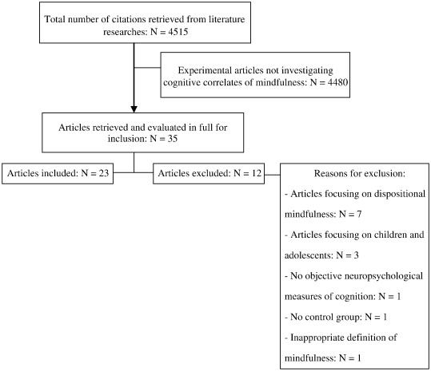

1. [Download: Download full-size image](https://ars.els-cdn.com/content/image/1-s2.0-S027273581000173X-gr1.jpg)

Fig. 1. Flow diagram of the review process.

Table 1. Excluded studies and reason for exclusion.

| Excluded studies | Reason for exclusion |
| --- | --- |
| Alexander, Langer, Newman, Chandler, and Davies (1989) | Inappropriate definition of mindfulness |
| Brown and Ryan (2003) | Dispositional mindfulness |
| Creswell, Way, Eisenberger, and Lieberman (2007) | Dispositional mindfulness |
| Haydicky (2010) | Non adult sample |
| Herndon (2008) | Dispositional mindfulness |
| Moore, Brody, and Dierberger (2009) | Dispositional mindfulness |
| Napoli, Krech, and Holley (2005) | Non adult sample |
| Schmertz, Anderson, and Robins (2009) | Dispositional mindfulness |
| Semple, Lee, Rosa, and Miller (2009) | Non adult sample |
| Slagter, Lutz, Greischar, Nieuwenhuis, and Davidson (2009) | No objective neuropsychological measures of cognitive functions |
| Waters et al. (2009) | Dispositional mindfulness |
| Zylowska et al. (2008) | Uncontrolled trial |

Table 2. Prospective controlled and randomized controlled studies providing objective measures of cognition following mindfulness training.

| Author (date) | Study design | Type of subjects | Number of subjects | MMP/control condition | Measures of cognition | Main findings |
| --- | --- | --- | --- | --- | --- | --- |
| Anderson et al. (2007) | RCT | Healthy | 39 33 | MBSR Waiting list | 4GC ODT ST VCPT | No improvements in MBSR group relative to control group on measures of attention. Improvements in mindfulness levels in MBSR group correlated with improvements in object detection |
| Chambers et al. (2008) | CT | Healthy | 20 20 | Vip. Retreat No practice | DSB WAIS IST | Significant improvements in sustained attention and working memory in the Vipassana group as compared with controls |
| Cusens et al. (2010) | CT | Chronic pain | 33 20 | Breath. Prog. TAU | CPT | No significant difference between groups at any time |
| Hargus et al. (2010) | RCT | Suicidal major depression | 14 13 | MBCT Waiting list | RSSI MACAM | Significant improvements in MBCT over control group in meta-awareness. Significant decreases in the control group in memory specificity at time 2 |
| Heeren et al. (2009) | CT | Healthy | 18 18 | MBCT Waiting list | AMT HT TMT VFT | Increased specific and decreased general autobiographical memories following MBCT. No significant differences on other measures |
| Jha et al. (2007) | CT | Healthy | 17 17 17 | MBSR Intens retr. No treatment | ANT | At time 1 expert concentrative meditators prior to intensive retreat demonstrated higher conflict monitoring as compared with naïve meditation subjects. At time 2 MBSR group showed higher orienting ab… |
| Jha et al. (2010) | CT | Military personnel before stress | 29 17 | MBMFT No treatment | OST | Improvements in working memory abilities in the high practice MBMFT group and decreases in the low practice MBMFT group and controls |
| Mcmillan et al. (2002) | CT | Traumatic brain injury | 48 38 | ACT Phys. Ex. No treatment | AMIPB PASAT TAE TMT | No significant difference on any measure |
| Ortner et al. (2007) | RCT | Healthy | 21 23 24 | MM Relaxation Waiting list | EIT | MM group showed a reduction from T1 to T2 in emotional interference from unpleasant pictures as compared with other groups |
| Polak (2009) | RCT | Healthy | 50 50 52 | Mindf. Induct. Relax. Induct. No treatment | ANT ST WRAML | At T2 mindfulness practitioners showed improved sustained attention abilities whereas relaxation group showed worsening on the same measure. No further significant differences |
| Slagter et al. (2007) | CT | Healthy | 17 23 | Vipas. Retr. No treatment | AB | Significant improvements on attentional blink in meditators in comparison with controls |
| Tang et al. (2007) | CT | Healthy | 40 40 | IMBTR Relaxation | ANT RM | Significant improvements in MMP group on conflict monitoring abilities |
| Wenk-Sormaz (2005) | RCT | Healthy | 20 20 20 | Mindf. Breath CLS Rest | ST WPT | Reduction in Stroop interference and significant improvements in meditators on unusual responding to the word production task |
| Williams et al. (2000) | RCT | Major depression | 21 20 | MBCT Waiting list | AMT | Significant group × time interaction related to a higher number of specific responses in meditators at T2 |
| Zeidan et al. (2010) | CT | Healthy | 24 25 | Brief Retreat Story listening | COWAT DSBF WIAS SDMT | Mindfulness training improved verbal fluency, visual coding and working memory, although only the first 2 measures were significantly higher in meditators than controls at endpoint |

Study design: CT = Controlled trial; RCT = Randomized controlled trial; MMP and control condition: ACT = Attentional control training; MBCT = Mindfulness based cognitive therapy; MBMFT = Mindfulness based mental fitness training; MBSR = Mindfulness based stress reduction; Mindf. Induct. = Mindfulness induction; MM = Mindfulness meditation; MMP = Mindfulness meditation practice; Phys. Ex. = Physical exercise; Relax. Induct. = Relaxation induction; Vip. = Vipassana; Measures of cognition: 4GC = circle appearing in the centre of 1 of 4 grids; AB = Attentional blink; AMIPB = Adult Memory and Information Processing Battery; AMT = Autobiographical memory test; ANT = attention network test; COWAT = Controlled Oral Word Association Test; CPT = Continuous performance task; DSB(F) WAIS = Digit span backward (and forward) of the Wechsler Adult Intelligence Scale; EIT = Emotional interference task; GST = Go/stop test; HT = Hayling task; IST = internal switching task; LM = Logical memory task of the Wechsler Memory Scale; MACAM = Measure of Awareness and Coping in Autobiographical Memory; ODT = object detection task; OST = Operation Span Task; PASAT = Paced auditory serial addition test; RM = Raven's standard progressive matrices; RSSI = Relapse signature specificity inventory; SDMY = Symbol Digit Modalities Test; ST = Stroop test; TEA = Test of everyday attention; TMT = Trail making test; VCPT: Vigil Continuous Performance Test; VFT = Verbal fluency task; VPA WAIS = Verbal Paired Associates subtests of the Wechsler Memory Scale; WPT = Word production task; WRAML = Wide Range Assessment of Memory and Learning.

Table 3. Case–control studies providing objective measures of cognition following mindfulness training.

| Author (date) | Type of subjects | Number of subjects | MMP/control condition | Measures of cognition | Main findings |
| --- | --- | --- | --- | --- | --- |
| Chan and Woollacott (2007) | Healthy | 30 20 10 | Meditators Meditators Controls | GLLT ST | Meditation experience, as measured by minutes of meditation/day, negatively correlated with Stroop interference and positively with reaction time on GLLT |
| Hodgins and Adair (2010) | Healthy | 100 100 | Meditators Controls | AIPST CBFT GV SAT | Mindfulness meditators significantly better than controls on measures of non directed attention, concentration accuracy, selective attention and attention switching. |
| Josefsson and Broberg (2010) | Healthy | 94 92 | Meditators Controls | SuAT ST | No significant difference on sustained attention and Stroop task. However longer meditation experience associated with faster SuAT reaction time |
| Moore and Malinowski (2009) | Healthy | 25 25 | Meditators Controls | CET ST | Both Stroop task scores and concentration and endurance test scores significantly related to meditation experience |
| Pagnoni and Cekic (2007) | Healthy | 13 13 | Meditators Controls | TRVIP | Significant inverse correlation between age and sustained attention in non meditators, no significant worsening related to age in meditators |
| Valentine and Sweet (1999) | Healthy | 8 11 24 | Meditators Meditators Controls | WCT | Meditation practice associated with higher sustained attention in comparison with controls, particularly in expert meditators. Mindfulness better than concentrative meditators when the stimulus was un… |
| Van den Hurk et al. (2010) | Healthy | 20 20 | Meditators Controls | ANT | Vipassana meditators significantly better on measures of sustained attention. A trend towards significance observed for executive attention |
| van Leeuwen et al. (2009) | Healthy | 17 17 17 | Meditators Age matched controls Younger controls | AB | Meditators showed levels of attention as high as younger controls and significantly higher levels of attention as compared with age matched controls |

MMP and control condition: MM = Mindfulness meditations; MMP = mindfulness meditation practice; Measures of cognition: AB = attentionsl blink; AIPST = Ambiguous image perspective-switching task; ANT = Attention network test; CBFT = Change blindness flickering task; CET = Concentration and endurance test; GLLT = Global local letters task; GV = Gorilla video; SAT = selective attention task; ST = Stroop test; SuAT = Sustained attention test; TRVIP = Task of visual information processing; WCT = Wilkins counting test.

Table 4. Description of included interventions.

| Author (date) | Interventions/conditions | Study duration | Number and duration of meetings | Lenght of daily practice* | Type of daily practice* | Prior meditation experience | Mean number of days/weeks between program completion and final neuropsychological assessment | Neuropsychological tests assessed immediately following a meditation session* |
| --- | --- | --- | --- | --- | --- | --- | --- | --- |
| *Prospective studies* |  |  |  |  |  |  |  |  |
| Anderson et al. (2007) | MBSR Waiting list | 8 weeks | 8 weekly meetings of 2 h | N.S. | Body scan, mindful stretching, mindfulness of breath/body/sounds/thoughts (in following boxes referred to as “common MMP exercises”) | No | 4 weeks | Yes |
| Chambers et al. (2008) | Vip. retreat No practice | 10 days | 10 sessions of about 10 h each | About 10 h | N.S. | No | 9 days | No |
| Cusens et al. (2010) | Breath. Prog. TAU | 8 weeks | 8 weekly meetings of 2.5 h | 30–45 min | Common MMP exercises | No | 0–4 weeks | N.S. |
| Hargus et al. (2010) | MBCT Waiting list | 3 months | 8 weekly meetings of 2 h | 45 min | Common MMP exercises | No | N.S. | N.S. |
| Heeren et al. (2009) | MBCT Waiting list | 8 weeks | 8 weekly meetings of 2 h | 45 min | Common MMP exercises | No | 5 days | N.S. |
| Jha et al. (2007) | MBSR Intens retr. No treatment | 8 weeks | MBSR: 8 weekly meetings of 3 h Intens retr: 30 sessions of about 10–12 h each | MBSR: 30 min Intens retr: 10–12 h | MBSR: Common MMP exercises Intens retr. group: mainly sitting and walking MM practice | MBSR and no treatment groups: no experience. Intens retreat group: 4–360 months of prior concentrative meditation experience | ≤ 10 days for MBSR group; immediately following the retreat for intens retr. group | N.S. |
| Jha et al. (2010) | MBMFT No treatment | 8 weeks | 8 weekly meetings of 3 h and a full-day retreat | 30 min | Common MMP exercises | No | N.S. | N.S. |
| Mcmillan et al. (2002) | ACT Phys. Ex. No treatment | 4 weeks | 4 weekly meetings of unspecified duration | N.S. | Common MMP exercises | No | Immediately following the training and at 52 weeks | N.S. |
| Ortner et al. (2007) | MM Relaxation Waiting list | 7 weeks | 7 weekly meetings of 1.5 h | N.S. | Common MMP, visualizations and mantras | Various ranging from 1 month to 29 years of prior mindfulness (Tibetan or Vipassana) practice | N.S. | N.S. |
| Polak (2009) | Mindf. Induct. Relax. Induct. No treatment | 2 days | 2 sessions of 15 min each | None | Focused attention on the breath | No | Immediately following the second session | Yes |
| Slagter et al. (2007) | Vipas. Retr. No treatment | 3 months | 30 sessions of about 10–12 h each | 10–12 h | Concentrative meditation followed by a non-reactive form of the whole sensory awareness | Expert meditators with different backgrounds | N.S. | No |
| Tang et al. (2007) | IMBTR Relaxation | 5 days | 5 daily sessions | 20 min | Effortless meditation characterized by restful alertness | No | N.S. | N.S |
| Wenk-Sormaz (2005) | Mindf. Breath CLS Rest | 1 day | A single session of 20 min | 20 min | Mindful attention on the breath | No | Immediately following the session | Yes |
| Williams et al. (2000) | MBCT Waiting list | 6 months | 8 weekly meetings of 2 h | 45 min | Common MMP exercises | No | 4 months | N.S. |
| Zeidan et al. (2010) | Brief Retreat Story listening | 4 days | 4 daily sessions | N.S | Focus on the breath and on any sensations that arose in the body1 | No | Immediately | Yes |
| *Case–control studies* |  |  |  |  |  |  |  |  |
| Chan and Woollacott (2007) | Meditators Meditators Controls | N.A | N.A | 6–150 min | Various meditation practices: meditators divided depending on the their main practices into concentrative and mindfulness meditators | Expert mindfulness and concentrative meditators (total hours of practice 82–19200 h) compared with novices | N.A. | N.S. |
| Hodgins and Adair (2010) | Meditators Controls | N.A | N.A | N.S. | Various mindfulness meditation practices | N.S. | N.A | N.S. |
| Josefsson and Broberg (2010) | Meditators Controls | N.A | N.A | N.S. | Various mindfulness meditation practices | Meditators with various degree of experience (1 month–>15 years) compared with novices | N.A | No |
| Moore and Malinowski (2009) | Meditators Controls | N.A | N.A | N.S. | Unspecified MM | Meditators with various degrees of experience (at least 6 weeks) compared with novices | N.A | N.S. |
| Pagnoni and Cekic (2007) | Meditators Controls | N.A | N.A | N.S. | Complete openness to one's own mental Processes | Meditators with at least 3 years of daily practice compared with novices | N.A | N.S. |
| Valentine and Sweet (1999) | Meditators Meditators Controls | N.A | N.A | N.S. | MM: Extended attention/awareness to as many events as possible. Concentrativer meditators: focused attention on a single point | N.S. | N.A | Yes |
| Van den Hurk et al. (2010) | Meditators Controls | N.A | N.A | 8–60 min | Both concentrative and mindfulness meditation used in Vipassana tradition | Meditators with a mean meditation experience of 14.5 years compared with novices | N.A | N.S. |
| van Leeuwen et al. (2009) | Meditators Age matched controls Younger controls | N.A | N.A | N.S. | Mainly mindful attention on the breath | Meditators with 1–29 years of experience compared with age matched and younger novices | N.A | N.S. |

Interventions and conditions: ACT = Attentional control training; MBCT = Mindfulness based cognitive therapy; MBMFT = Mindfulness based mental fitness training; MBSR = Mindfulness based stress reduction; Mindf. Induct. = Mindfulness induction; MM = Mindfulness meditation; MMP = Mindfulness meditation practice; Phys. Ex. = Physical exercise; Relax. Induct. = Relaxation induction; Vip. = Vipassana. Further abbreviations: N.A. = not applicable; N.S. = not specified; * = details reported in these columns are referred to the active conditions only.

### 3.2. Characteristics of included studies

Box1

Main neuropsychological tests mentioned in the manuscript.

| *Attentional tests* |  |
| --- | --- |
| Attention network test | Attention assay that uses the Ericksen flanker task as a target. It requires participants to determine whether a central arrow points left or right. Three subtractions provide scores for alerting, ori… |
| Attentional blink | Process where if a second target stimulus of two target stimuli is presented within 500 ms of the first one in a rapid sequence of distracters, it is often not detected |
| Continuous performance task | Attention assay in which participants are required to press a space bar immediately following presentation of any letter except an X and inhibit responding on presentation of an X |
| D2-concentration and endurance test | Timed test of selective attention with 14 rows each consisting of 47 items. The task is to discriminate and cancel through targets from visually similar non-targets |
| Global local letters task | Task in which participants must read letters that are made up by a bunch of tiny letters. They then must process either the large letter or the smaller letters that makes up the large letter. |
| Internal switching task | Psychological test that involves maintaining a count of how many words of a given category are serially presented on a computerized display. During this task, subjects are asked to maintain a silent m… |
| Stroop test | Test measuring executive attentional functioning by demanding that participants ignore their habitual and automatised process of word reading, in favor of attending to and responding to a less typical… |
| Trail making tests | Trail making test (TMT) part A involves drawing a line connecting consecutive numbers from 1 to 25. TMT part B involves drawing a similar line that connects alternating numbers and letters in sequence… |
| Vigil Continuous Performance Test | Attention test designed to tap sustained attention. Single letters are presented masked by visual noises. Participants are instructed to press the spacebar as quickly as possible when they see a given… |
| Wilkins counting test | Attention test consisting of series of binaural auditory bleeps at different rates pre-recorded on cassette audiotapes. The task is to count the bleeps and report the number presented at the end of ea… |
| *Memory tests* |  |
| Autobiographical memory test | Psychological test consisting of two lists of 10 emotional cue words. Participants are required to retrieve a specific memory in response to each cue word. |
| Digit span backward and forward of the Wechsler Adult Intelligence | Memory test in which subjects are requested to either correctly repeat or recite back a span of up to16 digits (14 digits backwards). Higher scores are indicative of higher memory recall. |
| Operation Span Task | Psychological test frequently used to index working memory capacity. It involves remembering non-affective stimuli such as letters over short intervals while performing simple arithmetic tasks. |
| Wide Range Assessment of Memory and Learning | Measure of short-term memory, in which the experimenter read a list of 16 words four times and asks participants to recall as many words as possible after each reading. |
| *Tests of executive functions* |  |
| Controlled Oral Word Association Test | It is a measure of a person's ability to make verbal associations to specified letters (verbal fluency) which is able to detect changes in word association fluency often found with various disorders |
| Hayling task | Test used to assess the capacity to inhibit cognitive prepotent responses. In the automatic condition, the experimenter read aloud each sentence to the participant. The participant have to listen to t… |
| Word production task | In part 1, participants are presented with 10 category descriptions and are asked to generate items that belong to each category within 30 s. In part 2, participants are given 1 min to write as many w… |
| *Tests of miscellaneous measures of cognition* |  |
| Emotional interference task | Psychological test in which participants judge whether a tone is high- or low-pitched while viewing neutral, pleasant, or unpleasant pictures. Slowed reaction times are thought to reflect increased al… |
| Measure of Awareness and Coping in Autobiographical Memory | Psychological test in which participants are asked to recall and describe their symptoms. Participants' symptom descriptions are then classified as specific, extended, or categoric. More specific desc… |
| Raven's standard progressive matrices | Standard intelligence test which comprises 5 sets in which subjects are asked to identify the missing item that completes a given pattern. Items within each set become increasingly difficult, requirin… |

### 3.3. Effects of MMPs on attention

#### 3.3.1. Sustained attention

Ten studies (7 controlled or randomized controlled trials and 3 case–control studies) provided measures of sustained attention. Among the former 7 studies, only two observed significant improvements in sustained attention scores in MMP groups as compared with control groups. In the first of such studies (Chambers, Lo, & Allen, 2008), significant interaction effects of condition by group (p = 0.04), condition by time (p = 0.005) and time by group (p = 0.04) were observed, such that the Vipassana retreat group's overall reaction times (RTs) in the affective (but not in the neutral) condition of the internal switching task (Lo & Allen, submitted for publication) significantly improved from T1 to T2, whereas the controls' did not. In the second study comparing subjects with no prior meditation experience addressed either to a MBSR program or to a waiting list with expert concentrative meditators after a 1-month intensive mindfulness retreat, no significant difference was observed between two novice groups. However a significant reduction in RTs scores, as measured with the attention network test (ANT), was observed in the intensive retreat group as compared with novices (p < 0.001) (Jha, Krompinger, & Baime, 2007). It should be noted, however, that both studies were limited by a non randomized design which could introduce some biases such as undetected differences across groups.

On the other hand no significant difference was observed between meditators and controls in the remaining studies (Mcmillan et al., 2002, Polak, 2009, Tang et al., 2007). Note however that two of such studies tested the effects of mindfulness training in novices after very short periods of MMPs, including a 5 day retreat (Tang et al., 2007) and a 2 session induction (Polak, 2009) respectively, and 1 study focused on a sample of patients with traumatic brain injuries (Mcmillan et al., 2002). The remaining studies compared subjects addressed to a MBSR or a closely related intervention to a waiting list or a treatment as usual (TAU) respectively (Anderson et al., 2007, Cusens et al., 2010), finding no difference in sustained attention as measured with the Continuous performance test (CPT) (Halperin, Sharma, Greenblatt, & Schwartz, 1991). However, in one of such studies, significant improvements from T1 to T2 were observed in both groups (Anderson et al., 2007).

#### 3.3.2. Selective attention

Eight studies, 4 prospective and 4 case–control studies, investigated the effects of MMP on selective attention. The only non randomized controlled study in this group reporting significant changes following mindfulness training showed significant improvements on selective attention as measured with the ANT in the MBSR group as compared with the 1-month intensive retreat and control groups, reflecting an enhancement in the ability to exclude unwanted stimuli following early stages of practice (MBSR in novice meditators) but not in expert meditators specifically concerned with training their open monitoring faculty (Jha et al., 2007). However no significant difference was observed in other three studies, possibly because of excessively short practice in two studies (Polak, 2009, Tang et al., 2007) or differences in target population (people with traumatic brain injuries) in the remaining one (Mcmillan et al., 2002). It is worth mentioning, however, that in one of such studies a significant positive relationship was found between enhanced selective attention and increases in self reported mindfulness levels (Polak, 2009).

Interestingly, all four case–control studies showed significantly higher levels of selective attention in long term meditators as compared with controls, although with some specific differences across trials. In the Chan and Woollacott's (2007) study no correlation was found between the congruency effect score and meditation experience as measured with the Global local letters task. However, meditation experience, as measured by meditation minutes/day, was associated with faster response time across all trial types reaching significance in the global condition (p < 0.05). Additionally, Hodgins and Adair (2010) found that both meditators and non meditators had shorter RTs on valid rather than invalid cues of the Selective attention task. However meditators disengaged more quickly from incorrectly cued visual information and more flexibly re-directed attention to new information. Also, Van den Hurk, Giommi, Gielen, Speckens, and Barendregt (2010) observed that meditators showed a significantly smaller orienting network effect on RT data of the ANT than did controls and Moore and Malinowski (2009) found that higher selective attention abilities were both correlated with meditation experience and with self reported mindfulness levels. Similar to what we pointed out for case–control studies focusing on sustained attention it is worth mentioning, however, that results deriving from such studies do not allow to infer any causal relationship between MMP and enhanced selective attention, even though findings suggesting that meditation experience seems to be related to enhanced selective attention abilities could partially dampen such concerns.

#### 3.3.3. Executive attention

Executive attention was investigated in 5 prospective and 4 case–control studies. Two studies, 1 of which using the ANT (Tang et al., 2007) and another one (Wenk-Sormaz, 2005) using the Stroop task (Stroop, 1935), reported significant improvements on executive attention measures in mindfulness groups as compared with control groups which were not mediated by changes in arousal (Wenk-Sormaz, 2005). In addition, Jha et al. (2007) found that at baseline expert concentrative meditators demonstrated improved conflict monitoring performance relative to novice meditators as measured with the ANT. However, no significant difference was observed following treatment. A possible explanation for the latter finding was suggested to be related to an improvement of the control group scores at time 2, possibly related to task exposure effects or alternatively to possible floor effects in RT performance (Jha et al., 2007). Note, however, that only one of such studies employed a randomized controlled design (Wenk-Sormaz, 2005) and evidence deriving from the remaining studies (Jha et al., 2007, Tang et al., 2007) should be considered with caution. In addition, at the opposite of previous findings, Polak, 2009, Anderson et al., 2007 did not observe any improvement following mindfulness training. A possible explanation for Polak's findings (Polak, 2009) could be related to the short duration of the trial (only two sessions) whereas the reason why Anderson et al. (2007) did not find any difference remains unclear.

#### 3.3.4. Attention switching

Attention switching was explored in three prospective and 1 case–control study. None of the prospective studies observed any significant difference between active and control groups following mindfulness training (Anderson et al., 2007, Chambers et al., 2008, Heeren et al., 2009), preliminarily leading to the hypothesis that attention switching is not affected by MMP, at least by short term training. However, results from Hodgins and Adair's (2010) study comparing expert meditators with non meditators by means of the Ambiguous image perspective-switching task showed that meditators had higher abilities to identify more alternative perspectives of ambiguous images and to identify the first perspective more quickly than did non-meditators, providing preliminary support for the notion that enhanced attention switching faculty could result from long term rather than short term MMP.

#### 3.3.5. Further attentional abilities

In 2007, Slagter et al. (2007) were the first authors to investigate the effects of a 3 month Vipassana retreat on attentional blink, a process where if a second target stimulus (T2) of two target stimuli is presented within 500 ms of the first one (T1) in a rapid sequence of distracters, it is often not detected (Raymond, Shapiro, & Arnell, 1992), possibly as a result of a deficit in the ability to process two temporally close, meaningful stimuli (Shapiro, Arnell, & Raymond, 1997). The results of such study showed that the meditation group showed a significantly smaller attentional blink as compared with controls (p < 0.001). Additionally, such reduction in attentional blink size was associated with a reduction in brain resource allocation to T1, as reflected by a smaller T1-elicited p3b amplitude (Slagter et al., 2007). Interestingly, such results were further replicated in a case–control study (van Leeuwen, Muller, & Melloni, 2009) comparing expert mindfulness meditators with age matched and younger controls. In such study, not only the magnitude of the blink was larger for the age-matched control as compared with the meditation group, but the meditation group, stemming from an older population, performed even better than the young control group, even though performance on the attentional blink has been shown to drop with age.

In addition, Hodgins and Adair (2010) compared expert mindfulness meditators to non meditators using the Change blindness flickering task (Rensink, O'Regan, & Clark, 1997) as a measure of non directed attention, finding that meditators identified a greater number of changes in flickering scenes than non-meditators and noticed changes more quickly than non meditators. However no significant benefits were observed on measures of non directed attention in patients randomly assigned to a MBSR intervention as compared with patients assigned to a waiting list (Anderson et al., 2007). Note, however, that changes in mindfulness predicted changes in object detection in participants to MBSR program but not in controls. On the other hand, no significant benefits were observed in patients with traumatic brain injuries following a shortened version of MBSR as compared with controls (Mcmillan et al., 2002). It is noteworthy, however, that, in the absence of replications, such findings should be considered with caution and deserve further investigation.

### 3.4. Effects of MMPs on memory

#### 3.4.1. Working memory

The effects of MMPs on working memory were investigated in 3 prospective studies. Two of such studies investigated the effects of a 10 day and a 4 day mindfulness retreats respectively (Chambers et al., 2008, Zeidan et al., 2010) and investigated the effects of mindfulness training on working memory by means of the digit span backward and forward of the Wechsler Adult Intelligence Scale (The Psychological Corporation, 1997). Both studies found a significant improvement in working memory capacity following the retreat. However, only in Chambers et al. (2008) focusing on a retreat with a longer duration, meditators performed significantly better than controls at post-test. In addition, Jha, Stanley, Kiyonaga, Wong, and Gelfand (2010) investigated the potential benefits of a mindfulness based mental fitness training modeled on MBSR to counteract the loss of working memory abilities prior to exposure to stressful events, using the Operation span (Ospan) task (Unsworth, Heitz, Schrock, & Engle, 2005), which involves memory of non affective stimuli such as letters over short intervals while performing simple arithmetic counts. Ospan scores showed a trend towards improvement from T1 to T2 in the meditators group with higher meditation practice (p = 0.08), whereas they deteriorated over time in the control group, and in the meditation group with low practice (Jha et al., 2010). In addition, only among those with higher meditation practice an overall increase in positive affects and a decrease in negative affects, as measured with the Positive and Negative Affective Scale (Watson, Clark, & Tellegen, 1988), were observed, pointing out to the importance of persistent practice to achieve better results. Similar to a number of studies mentioned above, however, it is worth mentioning that such studies were limited by a non randomized design which could introduce some biases and should therefore be considered with caution.

#### 3.4.2. Memory specificity

One controlled and 2 randomized controlled studies investigated the effects of MBCT in comparison with a waiting list on the enhancements of memory specificity in formerly depressed patients with at least two prior depressive episodes (Hargus et al., 2010, Williams et al., 2000) or in healthy subjects (Heeren et al., 2009). The importance of memory specificity relies on recent findings suggesting that patients with a history of major depression show difficulties in retrieving specific autobiographical memories and tend to recall categorical overgeneral memories. These difficulties, have, in turn, been related to impaired social problem solving and difficulties in generating specific simulations of future events, and are considered as markers of vulnerability to future depression and delayed recovery from episodes of emotional disorders. Interestingly, a significant effect of MBCT was observed both in healthy and in formerly depressed patients (Hargus et al., 2010, Heeren et al., 2009, Williams et al., 2000), such that patients addressed to the MBCT program increased their ability to provide specific memories as compared with controls at post test. Also, Hargus et al. (2010) found that, while there was no significant difference between the MBCT + TAU and TAU group in the specificity of relapse signatures at baseline assessment, recollection of the relapse signature became less specific over time in participants in the TAU group, suggesting a protective effect of mindfulness training from a deterioration of memory specificity in formerly depressed patients with a history of suicidality. A main limitation of such studies was, however, the nature of the control groups (waiting list), which did not allow to distinguish specific from non specific effects of MBCT, suggesting the necessity of further investigation.

#### 3.4.3. Miscellaneous measures of memory

Only 2 studies (Mcmillan et al., 2002, Polak, 2009) investigated the effects of MMP on general measures of memory by means of either the Wide Range Assessment of Memory and Learning (Sheslow & Adams, 1990) or the Adult Memory and Information Processing Battery (Coughlan & Hollows, 1985), finding no significant support for possible benefits deriving from mindfulness training on these measures. Note however that critical issues concerning the short duration of one of such studies (2 days mindfulness induction) (Polak, 2009) and the population under examination, including only patients with traumatic brain injuries, in the other (Mcmillan et al., 2002) could explain why negative findings have been observed and point out the necessity of a more thorough investigation of the effects of adequate mindfulness training on measures of memory other than working memory and memory specificity.

### 3.5. Effects of MMPs on executive functions

Heeren et al. (2009) also found significant support for an effect of MBCT on the inhibition of cognitive prepotent responses. They observed that the mindfulness group, which initially showed similar performances as compared with the matched control group as measured with the Hayling task, reported significantly fewer errors after the intervention (p < 0.001). However, no significant difference between groups was observed in the go/stop paradigm, possibly reflecting a higher ability of meditators to reduce cognitive prepotent responses in comparison with motor behaviors.

### 3.6. Effects of MMPs on miscellaneous measures of cognition

Of further interest is the finding that, although comparable at baseline, a group of formerly depressed patients randomly assigned to MBCT in adjunct to TAU as compared with subjects assigned to TAU only, displayed significant post treatment increases in meta-awareness (i.e. one's relationship with his/her own mental contents characterized by experiencing thoughts and emotions non conceptually as transient mental events rather than as truths or as definitions of self; Hargus et al., 2010). At the opposite of previous findings, however, Tang et al. (2007) found only partial support for the notion that a 5 day mindfulness intervention could improve intelligence levels as measured by means of Raven standard progressive matrices over simple relaxation training (p = 0.08). It is worth mentioning, however, that because such findings still lack replications, and in some cases they do not allow to distinguish specific from non specific effects of MMP (Hargus et al., 2010) or the effects of mindfulness trainings of longer duration (Tang et al., 2007), they should be considered with particular caution. Nevertheless, they point out the importance of further higher quality research to determine the potential benefits resulting from mindfulness training on several domains of cognitive function.

## 4. Discussion

The aim of the present work was to review current evidence about effects of MMPs on objective measures of cognitive functions, including attention, memory, executive functions and further measures of cognition. Several meaningful results have been observed. First of all we hypothesized that even a moderately brief mindfulness training such as an 8 week meditation program or a short term intensive retreat could improve sustained and particularly selective and executive attention as well as attention switching in subjects with no prior meditation experience. Of note, reviewed findings provide preliminary evidence for such hypothesis. First of all, when mindfulness training was investigated by means of properly delivered meditation programs, significant benefits were observed following MMP in comparison with no treatment (Chambers et al., 2008, Jha et al., 2007) or relaxation conditions (Tang et al., 2007). The only exception was characterized by the apparent lack of benefits deriving from MMP in comparison with control conditions with respect to attention switching (Anderson et al., 2007, Chambers et al., 2008, Heeren et al., 2009). Such observation led some authors to suggest that attention switching could be relatively insensitive to the type of manipulations represented by mindfulness training (Cusens et al., 2010) or alternatively that it could be a marker of more advanced MMP.

Of note, the only hypothesis that was not supported by empirical evidence concerned the lack of improvements of executive attention in expert concentrative meditators following a mindfulness retreat in comparison with novice meditators addressed to MBSR or to a waiting list (Jha et al., 2007). Note, however, that long term meditators overall performed better than matched controls on measures of executive attention. On the basis of such finding, one could hypothesize that the development of executive attention occurs early during concentrative/mindfulness training or alternatively that is more specifically associated with concentrative rather than with mindfulness training. Accordingly, it could not show further improvements during pure mindfulness practice where attention is equally distributed across all external and internal stimuli (Lutz, Slagter, et al., 2008). However such hypothesis has yet to be verified within the context of experimental research.

We also predicted that MMPs could enhance memory, in particular working memory. Overall, reviewed findings preliminarily suggest that MMP could be related to enhanced working memory capacity as well as to a prevention of loss of working memory abilities prior to exposure to stressful stimuli (Chambers et al., 2008, Jha et al., 2010, Zeidan et al., 2010). In addition, Jha et al. (2010), along with a number of studies mentioned above (Chan and Woollacott, 2007, Pagnoni and Cekic, 2007, Valentine and Sweet, 1999), provided further evidence to suggest that the effects of mindfulness training could be related to the amount of meditation practice, providing additional evidence as to how it could not be the mere participation to a mindfulness meditation program that produces clinical changes but rather the quantity and quality of meditation practice one employs. Similarly, MMP was related to increased memory specificity, a psychological marker of mental well being. Increased memory specificity, in fact, can be considered as opposite to overgeneral memories, which have been related to impaired social problem solving (Goddard, Dritschel, & Burton, 1997), and are considered as markers of vulnerability to future depression (van Minnen, Wessel, Verhaak, & Smeenk, 2005) and delayed recovery from episodes of emotional disorders (Peeters, Wessel, Merckelbach, & Boon-Vermeeren, 2002). Finally, although less extensively investigated, executive functions, including verbal fluency and inhibition of cognitive responses, as well as further cognitive measures, such as meta-awareness and emotional interference from distracting stimuli, could be improved by mindfulness training as well. However, on account of the limited evidence about such topic and the number of shortcomings related to available studies such as the impossibility to distinguish between specific and non specific effects of MMP, such findings should be considered with caution and deserve further investigation.

### 4.1. Clinical implications

Despite the preliminary nature of these findings, it is worth mentioning that they could have a strong clinical impact. First of all, significant psychological benefits following mindfulness training are supposed to depend, at least partially, on the development of attentional control and other cognitive executive functions (Baer, 2003). As an example, the reduction of excessive elaborative processing of negative stimuli following MMPs, which presumably draws on limited processing resources (Ellis & Ashbrook, 1988), might otherwise be directed towards selecting and executing an optimal response to environmental contingencies. As a further example, subjects with low versus high working memory capacities are more likely to suffer from emotionally intrusive thoughts and are less successful at suppressing positive and negative emotions (Brewin and Smart, 2005, Schmeichel et al., 2008). However, working memory capacity is not an immutable individual factor, as it can be modified by mindfulness training (Jha et al., 2010). Also, there is some evidence suggesting that MMP could enhance psychological well being (e.g. Anderson et al., 2007, Jha et al., 2010, Ortner et al., 2007) and that benefits deriving from mindfulness training could increase proportionally with daily or total length of practice (Chan and Woollacott, 2007, Jha et al., 2010, Pagnoni and Cekic, 2007, Valentine and Sweet, 1999).

Note, however, that specific categories of subjects, such as people with traumatic brain injuries, could be less likely to benefit from mindfulness training (Mcmillan et al., 2002). Indeed, although Mcmillan et al. (2002) was limited by the investigation of a modified version of mindfulness training, it points out the possibility that mindfulness training could be helpful in certain conditions but not in others. As an example, Zylowska et al. (2008) recently reported significant psychological benefits as well as enhanced cognitive abilities in subjects with attention deficit and hyperactive disorder following mindfulness training, suggesting possible cognitive benefits deriving from MMP in subjects with impaired attention. On the other hand, other authors have speculated that MMP could be more useful to prevent rather than to treat age related disorders such as Alzheimer's disease or cognitive decline usually associated with age (e.g. Pagnoni & Cekic, 2007). This further raises several challenges for future research on this topic. They include, for instance, the search for a specificity profile of different subcomponents of mindfulness to understand which meditation practices are best used for cultivating different types of cognitive (and emotional) skills as well as the need to understand how the individuals' unique cognitive and affective styles could be best matched to specific forms of meditation.

### 4.2. Limitation of current evidence

A substantial number of limitations should be considered before firm conclusions could be drawn from reviewed studies. First of all a high number of studies compared mindfulness training to a waiting list which does not account for non specific effects of mindfulness training. In other words, it is difficult to ascertain to what extent a different intervention such as simple relaxation could lead to similar outcomes. It is noteworthy, however, that studies comparing MMPs with relaxation, simple rest or different types of meditation practices (Chan and Woollacott, 2007, Ortner et al., 2007, Tang et al., 2007, Valentine and Sweet, 1999) have either reported significantly higher cognitive performances in mindfulness meditators as compared with controls or different patterns of cognitive abilities following different meditation trainings. Such findings suggest that it is unlikely that they could be simply due to non specific effects of training.

Second, a substantial heterogeneity has been observed on specific domains of cognition. A large number of reasons could explain such discrepancies. A possible explanation could be simply imputed to differences in neuropsychological tests employed. However, a more intriguing explanation could be related to the notion that psychological tests used in current trials could lack sufficient sensitivity to detect changes following mindfulness training. A large number of MMPs, in fact, is specifically concerned with apperception (i.e., perception of internal phenomena) rather than with perception of external phenomena (Cusens et al., 2010). Interestingly, such issue further points out the possibility that even subtle differences in meditation instructions could be related to significantly different neuropsychological findings. It also suggests that tests of somatosensory attention deserve future consideration. In addition, we have observed a substantial heterogeneity in the types of practices encompassed under the mindfulness “umbrella term” as well as in their daily and total duration. Taking into account that negative findings were frequently related to the investigation of modified and non standardized versions of mindfulness training, our results point out the necessity of a more accurate investigation of existing standard mindfulness protocols so as to reduce possible sources of discrepancies across studies.

Additionally, significant variations in study design should also be considered. In particular, it is worth mentioning that positive results were frequently observed in case–control studies, which are carried out at one time point and do not allow to infer a causal relationship between MMP and enhanced cognitive ability. Accordingly, such studies should be considered with caution, as they do not allow to rule out the possibility that, as an example, higher pre-meditation cognitive abilities could be specific of subjects more prone to meditate as compared with control subjects. Note, however, that positive findings in some prospective studies focusing on properly delivered MMPs as well as the observed positive correlation between enhanced cognitive abilities and the amount of MMP in a number of case–control studies could partially dampen such concerns. On the other hand, even results deriving from prospective controlled studies should be considered with caution. The majority of such studies, in fact, was limited by a non randomized design that do not allow to exclude the existence of subtle undetected differences between subjects addressed to MMP groups as compared with those addressed to control groups. Accordingly, further higher quality research is needed to overcome the limitations related to available studies.

Moreover, the inclusion of very short mindfulness inductions could raise concerns as to whether such brief trainings could be related to observable changes in cognitive functions as well. However, as Williams (2010) has recently pointed out, one could answer that authors of such studies “are not trying to analogize a full mindfulness treatment program, but to bring about very short term changes that would need much longer to consolidate if they were going to bring about long-term benefit” (p. 3). The inclusion of different patient populations including both clinical and non clinical populations should also be considered. In addition, our review indirectly point out the necessity of a more deep investigation of possible effects of MMPs on different domains of memory and on further executive functions such as problem solving, which have not been systematically investigated so far.

Finally, one could call into question the categorization of cognitive functions employed in the present review. Cognitive functions are known to be significantly related to each other (e.g. McVay and Kane, 2009, Redick and Engle, 2006) and every attempt to categorize cognitive functions as distinct abilities could represent a simple heuristic rather than an objective distinction. However, as explained above, our categorization of cognitive functions was only used for clarity purposes. Additionally, we have referred to some of the most validated scientific models of cognition which have been linked to specific neurobiological areas as well (e.g. Corbetta and Shulman, 2002, Mirsky et al., 1991, Posner and Petersen, 1990).

## 5. Conclusion

In conclusion, the results of the present review provide preliminary support for the notion that MMPs could provide significant benefits on several measures of cognition which seem specific for the phase of meditation training under investigation. However, further higher quality studies focusing on more standardized MMPs are needed to replicate available findings, to more deeply explore the effects of mindfulness training on further domains of cognition and to reduce discrepancies of findings deriving from systematic differences in mindfulness protocols.

## References

1. Alexander et al., 1989

   C.N. Alexander, E.J. Langer, R. Newman, H.M. Chandler, J.L. Davies

   Transcendental meditation, mindfulness, and longevity: An experimental study with the elderly

   Journal of Personality and Social Psychology, 57 (1989), pp. 950-964

   [View in Scopus](https://www.scopus.com/inward/record.url?eid=2-s2.0-0024802079&partnerID=10&rel=R3.0.0)Google Scholar
2. Anderson et al., 2007

   N.D. Anderson, M.A. Lau, Z.V. Segal, S.R. Bishop

   Mindfulness-based stress reduction and attentional control

   Clinical Psychology & Psychotherapy, 14 (2007), pp. 449-463

   [View at publisher](https://ct.prod.getft.io/c2NpZW5jZWRpcmVjdF9jb250ZW50aG9zdGluZyx3aWxleSxodHRwczovL29ubGluZWxpYnJhcnkud2lsZXkuY29tL2RvaS9lcGRmLzEwLjEwMDIvY3BwLjU0ND9zcmM9Z2V0ZnRy.kxhJFwdBahkbHiyvLLt7SXzdTPKzS8wPYHuYuTzTya8)

   [Crossref](https://doi.org/10.1002/cpp.544)[View in Scopus](https://www.scopus.com/inward/record.url?eid=2-s2.0-37549032421&partnerID=10&rel=R3.0.0)Google Scholar
3. Ardila, 2008

   A. Ardila

   On the evolutionary origins of executive functions

   Brain and Cognition, 68 (2008), pp. 92-99

   [View PDF](https://www.sciencedirect.com/science/article/pii/S0278262608001656/pdfft?md5=13cb903f8f6c8cad7c20fb210aa50ebc&pid=1-s2.0-S0278262608001656-main.pdf)[View article](https://www.sciencedirect.com/science/article/pii/S0278262608001656)[View in Scopus](https://www.scopus.com/inward/record.url?eid=2-s2.0-52949117648&partnerID=10&rel=R3.0.0)[Google Scholar](https://scholar.google.com/scholar_lookup?title=On%20the%20evolutionary%20origins%20of%20executive%20functions&publication_year=2008&author=A.%20Ardila)
4. Baddeley, 1986

   A. Baddeley

   Working memory

   Oxford Univerisity Press, Oxford (1986)

   [Google Scholar](https://scholar.google.com/scholar_lookup?title=Working%20memory&publication_year=1986&author=A.%20Baddeley)
5. Baddeley, 1998

   A. Baddeley

   Recent developments in working memory

   Current Opinion in Neurobiology, 8 (1998), pp. 234-238

   [View PDF](https://www.sciencedirect.com/science/article/pii/S0959438898801451/pdf?md5=c99afcffa83747603c4c9366724dd7e9&pid=1-s2.0-S0959438898801451-main.pdf)[View article](https://www.sciencedirect.com/science/article/pii/S0959438898801451)[View in Scopus](https://www.scopus.com/inward/record.url?eid=2-s2.0-0032052648&partnerID=10&rel=R3.0.0)[Google Scholar](https://scholar.google.com/scholar_lookup?title=Recent%20developments%20in%20working%20memory&publication_year=1998&author=A.%20Baddeley)
6. Baddeley, 2010

   A. Baddeley

   Working memory

   Current Biology, 20 (2010), pp. R136-R140

   [View PDF](https://www.sciencedirect.com/science/article/pii/S0960982209021332/pdfft?md5=84885bf40f1d34e07bee6b728e8c9a50&pid=1-s2.0-S0960982209021332-main.pdf)[View article](https://www.sciencedirect.com/science/article/pii/S0960982209021332)[View in Scopus](https://www.scopus.com/inward/record.url?eid=2-s2.0-76749134009&partnerID=10&rel=R3.0.0)[Google Scholar](https://scholar.google.com/scholar_lookup?title=Working%20memory&publication_year=2010&author=A.%20Baddeley)
7. Baddeley and Hitch, 1974

   A. Baddeley, G.J.L. Hitch

   Working memory

   G.A. Bower (Ed.), The psychology of learning and motivation: Advances in research and theory, Vol. 8, Academic Press, New York (1974), pp. 47-89

   [View PDF](https://www.sciencedirect.com/science/article/pii/S0079742108604521/pdf?md5=c9ffd5987171df3ad921bfa25c0a3476&pid=1-s2.0-S0079742108604521-main.pdf)[View article](https://www.sciencedirect.com/science/article/pii/S0079742108604521)[Google Scholar](https://scholar.google.com/scholar_lookup?title=Working%20memory&publication_year=1974&author=A.%20Baddeley&author=G.J.L.%20Hitch)
8. Baer, 2003

   R.A. Baer

   Mindfulness training as a clinical intervention: A conceptual and empirical review

   Clinical Psychology: Science and Practice, 10 (2003), pp. 125-143

   [View in Scopus](https://www.scopus.com/inward/record.url?eid=2-s2.0-0142212095&partnerID=10&rel=R3.0.0)[Google Scholar](https://scholar.google.com/scholar_lookup?title=Mindfulness%20training%20as%20a%20clinical%20intervention%3A%20A%20conceptual%20and%20empirical%20review&publication_year=2003&author=R.A.%20Baer)
9. Baer et al., 2004

   R.A. Baer, G.T. Smith, K.B. Allen

   Assessment of mindfulness by self-report: The Kentucky inventory of mindfulness skills

   Assessment, 11 (2004), pp. 191-206

   [View in Scopus](https://www.scopus.com/inward/record.url?eid=2-s2.0-16544368923&partnerID=10&rel=R3.0.0)Google Scholar
10. Baer et al., 2006

    R.A. Baer, G.T. Smith, J. Hopkins, J. Krietemeyer, L. Toney

    Using self-report assessment methods to explore facets of mindfulness

    Assessment, 13 (2006), pp. 27-45

    [View at publisher](https://doi.org/10.1177/1073191105283504)[Crossref](https://doi.org/10.1177/1073191105283504)[View in Scopus](https://www.scopus.com/inward/record.url?eid=2-s2.0-33744510787&partnerID=10&rel=R3.0.0)Google Scholar
11. Benton, 1989

    A.L. Benton

    Multilingual aphasia examination

    AJA Associates, Iowa City, Iowa (1989)

    [Google Scholar](https://scholar.google.com/scholar_lookup?title=Multilingual%20aphasia%20examination&publication_year=1989&author=A.L.%20Benton)
12. Bishop et al., 2004

    S.R. Bishop, M. Lau, S. Shapiro

    Mindfulness: A proposed operational definition

    Clinical Psychology, 11 (2004), pp. 230-241

    [View in Scopus](https://www.scopus.com/inward/record.url?eid=2-s2.0-4344561308&partnerID=10&rel=R3.0.0)[Google Scholar](https://scholar.google.com/scholar_lookup?title=Mindfulness%3A%20A%20proposed%20operational%20definition&publication_year=2004&author=S.R.%20Bishop&author=M.%20Lau&author=S.%20Shapiro)
13. Bowen et al., 2006

    S. Bowen, K. Witkiewitz, T.M. Dillworth, N. Chawla, T.L. Simpson, B.D. Ostafin, *et al.*

    Mindfulness meditation and substance use in an incarcerated population

    Psychology of Addictive Behaviours, 20 (2006), pp. 343-347

    [View in Scopus](https://www.scopus.com/inward/record.url?eid=2-s2.0-33748664824&partnerID=10&rel=R3.0.0)Google Scholar
14. Brewer et al., 1998

    J.B. Brewer, Z. Zhao, J.E. Desmond, G.H. Glover, J.D. Gabrieli

    Making memories: Brain activity that predicts how well visual experience will be remembered

    Science, 281 (1998), pp. 1185-1187

    [View in Scopus](https://www.scopus.com/inward/record.url?eid=2-s2.0-0032555613&partnerID=10&rel=R3.0.0)Google Scholar
15. Brewin and Smart, 2005

    C.R. Brewin, L. Smart

    Working memory capacity and suppression of intrusive thoughts

    Journal of Behavioural Therapeutic & Experimental Psychiatry, 36 (2005), pp. 61-68

    [View PDF](https://www.sciencedirect.com/science/article/pii/S0005791604000965/pdfft?md5=08aa020e9f3a6f19add52a975d5deb6f&pid=1-s2.0-S0005791604000965-main.pdf)[View article](https://www.sciencedirect.com/science/article/pii/S0005791604000965)[View in Scopus](https://www.scopus.com/inward/record.url?eid=2-s2.0-15744364888&partnerID=10&rel=R3.0.0)[Google Scholar](https://scholar.google.com/scholar_lookup?title=Working%20memory%20capacity%20and%20suppression%20of%20intrusive%20thoughts&publication_year=2005&author=C.R.%20Brewin&author=L.%20Smart)
16. Brown, 1977

    D.P. Brown

    A model for the levels of concentrative meditation

    The International Journal of Clinical and Experimental Hypnosis, 25 (1977), pp. 236-273

    [View in Scopus](https://www.scopus.com/inward/record.url?eid=2-s2.0-0017757537&partnerID=10&rel=R3.0.0)[Google Scholar](https://scholar.google.com/scholar_lookup?title=A%20model%20for%20the%20levels%20of%20concentrative%20meditation&publication_year=1977&author=D.P.%20Brown)
17. Brown and Ryan, 2003

    K.W. Brown, R.M. Ryan

    The benefits of being present: Mindfulness and its role in psychological well.being

    Journal of Personality and Social Psychology, 84 (2003), pp. 822-848

    [View in Scopus](https://www.scopus.com/inward/record.url?eid=2-s2.0-0038673754&partnerID=10&rel=R3.0.0)Google Scholar
18. Brown and Ryan, 2004

    K.W. Brown, R.M. Ryan

    Perils and promise in defining and measuring mindfulness: Observations from experience

    Clinical Psychology Science & Practive, 11 (2004), pp. 242-248

    [View in Scopus](https://www.scopus.com/inward/record.url?eid=2-s2.0-4344636075&partnerID=10&rel=R3.0.0)Google Scholar
19. Buddhaghosa, 1976

    B. Buddhaghosa

    Vissuddhimagga (The path of purification)

    Shambala, Seattle (1976)

    [Google Scholar](https://scholar.google.com/scholar_lookup?title=Vissuddhimagga%20&publication_year=1976&author=B.%20Buddhaghosa)
20. Budson, 2009

    A.E. Budson

    Understanding memory dysfunction

    The Neurologist, 15 (2009), pp. 71-79

    [View in Scopus](https://www.scopus.com/inward/record.url?eid=2-s2.0-63449099901&partnerID=10&rel=R3.0.0)[Google Scholar](https://scholar.google.com/scholar_lookup?title=Understanding%20memory%20dysfunction&publication_year=2009&author=A.E.%20Budson)
21. Burgess and Shallice, 1996

    P.W. Burgess, T. Shallice

    Responses suppression, initiation and strategy use following frontal lobe lesions

    Neuropsychologia, 34 (1996), pp. 263-273

    [View in Scopus](https://www.scopus.com/inward/record.url?eid=2-s2.0-0029877606&partnerID=10&rel=R3.0.0)Google Scholar
22. Chambers et al., 2009

    R. Chambers, E. Gullone, N.B. Allen

    Mindful emotion regulation: An integrative review

    Clinical Psychology Review, 29 (2009), pp. 560-572

    [View PDF](https://www.sciencedirect.com/science/article/pii/S0272735809000865/pdfft?md5=ef4d0c0371266ea8c2b1a78cf3f5c1a1&pid=1-s2.0-S0272735809000865-main.pdf)[View article](https://www.sciencedirect.com/science/article/pii/S0272735809000865)[View in Scopus](https://www.scopus.com/inward/record.url?eid=2-s2.0-68049109237&partnerID=10&rel=R3.0.0)[Google Scholar](https://scholar.google.com/scholar_lookup?title=Mindful%20emotion%20regulation%3A%20An%20integrative%20review&publication_year=2009&author=R.%20Chambers&author=E.%20Gullone&author=N.B.%20Allen)
23. Chambers et al., 2008

    R. Chambers, B.C.Y. Lo, N.B. Allen

    The impact of intensive mindfulness training on attentional control, cognitive style and affect

    Cognitive Therapy & Research, 32 (2008), pp. 303-322

    [View at publisher](https://doi.org/10.1007/s10608-007-9119-0)[Crossref](https://doi.org/10.1007/s10608-007-9119-0)[View in Scopus](https://www.scopus.com/inward/record.url?eid=2-s2.0-43549098809&partnerID=10&rel=R3.0.0)Google Scholar
24. Chan and Woollacott, 2007

    D. Chan, M. Woollacott

    Effects of level of meditation experience on attentional focus: Is the efficiency of executive or orientation networks improved?

    Journal of Alternative and Complementary Medicine, 13 (2007), pp. 651-657

    [View in Scopus](https://www.scopus.com/inward/record.url?eid=2-s2.0-34548446264&partnerID=10&rel=R3.0.0)Google Scholar
25. Chiesa, 2009

    A. Chiesa

    Zen meditation: An integration of current evidence

    Journal of Alternative and Complementary Medicine, 15 (2009), pp. 585-592

    [View at publisher](https://doi.org/10.1089/acm.2008.0416)[Crossref](https://doi.org/10.1089/acm.2008.0416)[View in Scopus](https://www.scopus.com/inward/record.url?eid=2-s2.0-67149102546&partnerID=10&rel=R3.0.0)[Google Scholar](https://scholar.google.com/scholar_lookup?title=Zen%20meditation%3A%20An%20integration%20of%20current%20evidence&publication_year=2009&author=A.%20Chiesa)
26. Chiesa and Malinowski, submitted for publication

    Chiesa, A., & Malinowski, P. (in press). Mindfulness based approaches: Are they all the same? *Journal of Clinical Psychology*.

    Google Scholar
27. Chiesa and Serretti, 2009

    A. Chiesa, A. Serretti

    Mindfulness-based stress reduction for stress management in healthy people: A review and meta-analysis

    Journal of Alternative and Complementary Medicine, 15 (2009), pp. 593-600

    [View at publisher](https://doi.org/10.1089/acm.2008.0495)[Crossref](https://doi.org/10.1089/acm.2008.0495)[View in Scopus](https://www.scopus.com/inward/record.url?eid=2-s2.0-67149130345&partnerID=10&rel=R3.0.0)Google Scholar
28. Chiesa and Serretti, in press

    Chiesa, A., & Serretti, A. (in press). Mindfulness based meditations for chronic pain: A systematic review of the evidence. *Journal of Alternative and Complementary Medicine*.

    Google Scholar
29. Chiesa and Serretti, 2010

    A. Chiesa, A. Serretti

    A systematic review of neurobiological and clinical features of mindfulness meditations

    Psychological Medicine, 40 (2010), pp. 1239-1252

    [View in Scopus](https://www.scopus.com/inward/record.url?eid=2-s2.0-77957130022&partnerID=10&rel=R3.0.0)Google Scholar
30. Coelho et al., 2007

    H.F. Coelho, P.H. Canter, E. Ernst

    Mindfulness-based cognitive therapy: Evaluating current evidence and informing future research

    Journal of Consulting and Clinical Psychology, 75 (2007), pp. 1000-1005

    [View in Scopus](https://www.scopus.com/inward/record.url?eid=2-s2.0-38149057215&partnerID=10&rel=R3.0.0)Google Scholar
31. Corbetta and Shulman, 2002

    M. Corbetta, G.L. Shulman

    Control of goal-directed and stimulus-driven attention in the brain

    Nature Review Neuroscience, 3 (2002), pp. 201-215

    [View at publisher](https://doi.org/10.1038/nrn755)[Crossref](https://doi.org/10.1038/nrn755)[View in Scopus](https://www.scopus.com/inward/record.url?eid=2-s2.0-0036517313&partnerID=10&rel=R3.0.0)[Google Scholar](https://scholar.google.com/scholar_lookup?title=Control%20of%20goal-directed%20and%20stimulus-driven%20attention%20in%20the%20brain&publication_year=2002&author=M.%20Corbetta&author=G.L.%20Shulman)
32. Coughlan and Hollows, 1985

    A.K. Coughlan, S.E. Hollows

    The AdultMemory and Information Processing Battery test manual

    Psychology Department, University of Leeds, Leeds, UK (1985)

    [Google Scholar](https://scholar.google.com/scholar_lookup?title=The%20AdultMemory%20and%20Information%20Processing%20Battery%20test%20manual&publication_year=1985&author=A.K.%20Coughlan&author=S.E.%20Hollows)
33. Creswell et al., 2007

    J.D. Creswell, B.M. Way, N.I. Eisenberger, M.D. Lieberman

    Neural correlates of dispositional mindfulness during affect labeling

    Psychosomatic Medicine, 69 (2007), pp. 560-565

    [View in Scopus](https://www.scopus.com/inward/record.url?eid=2-s2.0-34547637208&partnerID=10&rel=R3.0.0)Google Scholar
34. Cusens et al., 2010

    B. Cusens, G.B. Duggan, K. Thorne, V. Burch

    Evaluation of the breathworks mindfulness-based pain management programme: Effects on well-being and multiple measures of mindfulness

    Clinical Psychology & Psychotherapy, 17 (2010), pp. 63-78

    [View at publisher](https://doi.org/10.1002/cpp.653)[Crossref](https://doi.org/10.1002/cpp.653)[View in Scopus](https://www.scopus.com/inward/record.url?eid=2-s2.0-77249084342&partnerID=10&rel=R3.0.0)Google Scholar
35. Das, 1997

    S. Das

    Awakening the Buddha within

    Broadway, New York (1997)

    [Google Scholar](https://scholar.google.com/scholar_lookup?title=Awakening%20the%20Buddha%20within&publication_year=1997&author=S.%20Das)
36. Davidson, 2010

    R.J. Davidson

    Empirical explorations of mindfulness: Conceptual and methodological conundrums

    Emotion, 10 (2010), pp. 8-11

    [View at publisher](https://doi.org/10.1037/a0018480)[Crossref](https://doi.org/10.1037/a0018480)[View in Scopus](https://www.scopus.com/inward/record.url?eid=2-s2.0-77249114194&partnerID=10&rel=R3.0.0)[Google Scholar](https://scholar.google.com/scholar_lookup?title=Empirical%20explorations%20of%20mindfulness%3A%20Conceptual%20and%20methodological%20conundrums&publication_year=2010&author=R.J.%20Davidson)
37. Dougherty et al., 2003

    Dougherty D.M., Mathias C.W., Marsh D.M.

    Gostop Impulsivity Paradigm (Version 1.0)

    Neurobehavioral Research Laboratory and Clinic, University of Texas Health Science Center, Houston, TX (2003)

    [Google Scholar](https://scholar.google.com/scholar_lookup?title=Gostop%20Impulsivity%20Paradigm%20&publication_year=2003&author=D.M.%20Dougherty&author=C.W.%20Mathias&author=D.M.%20Marsh)
38. Ellis and Ashbrook, 1988

    Ellis H.C., Ashbrook P.W.

    Resource allocation model of the effects of depressed mood states on memory

    Forgas K.F.J. (Ed.), Affect, cognition and social behavior, Hogrefe, Tornonto (1988), pp. 25-43

    [View at publisher](https://doi.org/10.1002/jmr.300010106)[Crossref](https://doi.org/10.1002/jmr.300010106)Google Scholar
39. Erisman and Roemer, 2010

    S.M. Erisman, L. Roemer

    A preliminary investigation of the effects of experimentally induced mindfulness on emotional responding to film clips

    Emotion, 10 (2010), pp. 72-82

    [View at publisher](https://doi.org/10.1037/a0017162)[Crossref](https://doi.org/10.1037/a0017162)[View in Scopus](https://www.scopus.com/inward/record.url?eid=2-s2.0-77249158364&partnerID=10&rel=R3.0.0)Google Scholar
40. Forte et al., 1987–1988

    Forte, M., Brown, D. P., & Dysart, M. (1987–1988). Differences in experience among mindfulness meditators. *Imagination, Cognition & Personality, 7*, 47–60.

    Google Scholar
41. Goddard et al., 1997

    L. Goddard, B. Dritschel, A. Burton

    Social problem solving and autobiographical memory in non-clinical depression

    The British Journal of Clinical Psychology, 36 (Pt 3) (1997), pp. 449-451

    [View at publisher](https://doi.org/10.1111/j.2044-8260.1997.tb01252.x)[Crossref](https://doi.org/10.1111/j.2044-8260.1997.tb01252.x)[View in Scopus](https://www.scopus.com/inward/record.url?eid=2-s2.0-0030959697&partnerID=10&rel=R3.0.0)Google Scholar
42. Gruber and Goschke, 2004

    O. Gruber, T. Goschke

    Executive control emerging from dynamic interactions between brain systems mediating language, working memory and attentional processes

    Acta Psychologica (Amst), 115 (2004), pp. 105-121

    [View PDF](https://www.sciencedirect.com/science/article/pii/S0001691803001112/pdfft?md5=9e21e40cae0c3ba351fa7e20a92f65c0&pid=1-s2.0-S0001691803001112-main.pdf)[View article](https://www.sciencedirect.com/science/article/pii/S0001691803001112)[View in Scopus](https://www.scopus.com/inward/record.url?eid=2-s2.0-0842325231&partnerID=10&rel=R3.0.0)Google Scholar
43. Gunaratana, 1993

    H. Gunaratana

    Mindfulness in plain English

    Wisdom Publications, Boston (1993)

    [Google Scholar](https://scholar.google.com/scholar_lookup?title=Mindfulness%20in%20plain%20English&publication_year=1993&author=H.%20Gunaratana)
44. Halperin et al., 1991

    J.M. Halperin, V. Sharma, V. Greenblatt, S.T. Schwartz

    Assessment of the Continuous Performance Test: Reliability and validity in a nonreferred sample

    Psychological Assessment, 3 (1991), pp. 603-608

    [View in Scopus](https://www.scopus.com/inward/record.url?eid=2-s2.0-0000127393&partnerID=10&rel=R3.0.0)Google Scholar
45. Hargus et al., 2010

    E. Hargus, C. Crane, T. Barnhofer, J.M. Williams

    Effects of mindfulness on meta-awareness and specificity of describing prodromal symptoms in suicidal depression

    Emotion, 10 (2010), pp. 34-42

    [View at publisher](https://doi.org/10.1037/a0016825)[Crossref](https://doi.org/10.1037/a0016825)[View in Scopus](https://www.scopus.com/inward/record.url?eid=2-s2.0-77249172665&partnerID=10&rel=R3.0.0)Google Scholar
46. Haydicky, 2010

    J.A. Haydicky

    Mindfulness training for adolescents with learning disabilities

    University of Toronto, Toronto (2010)

    [Google Scholar](https://scholar.google.com/scholar_lookup?title=Mindfulness%20training%20for%20adolescents%20with%20learning%20disabilities&publication_year=2010&author=J.A.%20Haydicky)
47. Hayes and Feldman, 2004

    Hayes A.M., Feldman G.C.

    Clarifying the construct of mindfulness in the context of emotion regulation and the process of change in therapy

    Clinical Psychology Science & Practice, 11 (2004), pp. 255-262

    [View in Scopus](https://www.scopus.com/inward/record.url?eid=2-s2.0-4344673623&partnerID=10&rel=R3.0.0)Google Scholar
48. Hayes, 1994

    Hayes, S. C. (1994). Context, contents and the type of psychological acceptance. In N. J. S. Hayes, V. Follette, & M. Dougher (Eds.). (Ed.), *Acceptance and change: Content and context in psychotherapy*. Reno: Context Press.

    Google Scholar
49. Hayes et al., 2004

    S.C. Hayes, K. Strosahl, K.G. Wilson, R.T. Bisset, J. Pistorello, D. Toarmino, *et al.*

    Measuring experiential avoidance: A preliminary test of a working model

    Psychological Records, 54 (2004), pp. 553-578

    [View at publisher](https://doi.org/10.1007/BF03395492)[Crossref](https://doi.org/10.1007/BF03395492)[View in Scopus](https://www.scopus.com/inward/record.url?eid=2-s2.0-11144355427&partnerID=10&rel=R3.0.0)Google Scholar
50. Hayes et al., 1999

    Hayes S.C., Strosahl K.D., Wilson K.G.

    Acceptance and commitment therapy: An experimental approach to behaviour change. New York

    (1999)

    Google Scholar
51. Heeren et al., 2009

    A. Heeren, N. Van Broeck, P. Philippot

    The effects of mindfulness on executive processes and autobiographical memory specificity

    Behaviour Research and Therapy, 47 (2009), pp. 403-409

    [View PDF](https://www.sciencedirect.com/science/article/pii/S0005796709000254/pdfft?md5=2d3244924265a2360c8c156558c5ffd9&pid=1-s2.0-S0005796709000254-main.pdf)[View article](https://www.sciencedirect.com/science/article/pii/S0005796709000254)[View in Scopus](https://www.scopus.com/inward/record.url?eid=2-s2.0-65049089256&partnerID=10&rel=R3.0.0)Google Scholar
52. Henke, 2010

    K. Henke

    A model for memory systems based on processing modes rather than consciousness

    Nature Review Neuroscience, 11 (2010), pp. 523-532

    [View at publisher](https://doi.org/10.1038/nrn2850)[Crossref](https://doi.org/10.1038/nrn2850)[View in Scopus](https://www.scopus.com/inward/record.url?eid=2-s2.0-77953807450&partnerID=10&rel=R3.0.0)[Google Scholar](https://scholar.google.com/scholar_lookup?title=A%20model%20for%20memory%20systems%20based%20on%20processing%20modes%20rather%20than%20consciousness&publication_year=2010&author=K.%20Henke)
53. Herndon, 2008

    F. Herndon

    Testing mindfulness with perceptual and cognitive factors: External vs. internal encoding, and the cognitive failures questionnaire

    Personality and Individual Differences, 44 (2008), pp. 32-41

    [View PDF](https://www.sciencedirect.com/science/article/pii/S0191886907002498/pdfft?md5=3347ef2e39f7f72bccaa1e0f3d9d080f&pid=1-s2.0-S0191886907002498-main.pdf)[View article](https://www.sciencedirect.com/science/article/pii/S0191886907002498)[View in Scopus](https://www.scopus.com/inward/record.url?eid=2-s2.0-35248861100&partnerID=10&rel=R3.0.0)Google Scholar
54. Hodgins and Adair, 2010

    Hodgins H.S., Adair K.C.

    Attentional processes and meditation

    Consciousness and Cognition (2010)

    [Google Scholar](https://scholar.google.com/scholar_lookup?title=Attentional%20processes%20and%20meditation&publication_year=2010&author=H.S.%20Hodgins&author=K.C.%20Adair)
55. Ivanovski and Malhi, 2007

    B. Ivanovski, G.S. Malhi

    The psychological and neurophysiological concomitants of mindfulness forms of meditation

    Acta neuropsychiatrica, 19 (2007), pp. 76-91

    [View at publisher](https://doi.org/10.1111/j.1601-5215.2007.00175.x)[Crossref](https://doi.org/10.1111/j.1601-5215.2007.00175.x)[View in Scopus](https://www.scopus.com/inward/record.url?eid=2-s2.0-34247147669&partnerID=10&rel=R3.0.0)Google Scholar
56. Jha et al., 2007

    A.P. Jha, J. Krompinger, M.J. Baime

    Mindfulness training modifies subsystems of attention

    Cognitive & Affective Behaviour & Neuroscience, 7 (2007), pp. 109-119

    [View in Scopus](https://www.scopus.com/inward/record.url?eid=2-s2.0-34250821721&partnerID=10&rel=R3.0.0)[Google Scholar](https://scholar.google.com/scholar_lookup?title=Mindfulness%20training%20modifies%20subsystems%20of%20attention&publication_year=2007&author=A.P.%20Jha&author=J.%20Krompinger&author=M.J.%20Baime)
57. Jha et al., 2010

    A.P. Jha, E.A. Stanley, A. Kiyonaga, L. Wong, L. Gelfand

    Examining the protective effects of mindfulness training on working memory capacity and affective experience

    Emotion, 10 (2010), pp. 54-64

    [View at publisher](https://doi.org/10.1037/a0018438)[Crossref](https://doi.org/10.1037/a0018438)[View in Scopus](https://www.scopus.com/inward/record.url?eid=2-s2.0-77249105416&partnerID=10&rel=R3.0.0)Google Scholar
58. Josefsson and Broberg, 2010

    Josefsson T., Broberg A.

    Meditators and non-meditators on sustained and executive attentional performance

    Mental Health, Religion & Culture, Online publication (2010)

    [Google Scholar](https://scholar.google.com/scholar_lookup?title=Meditators%20and%20non-meditators%20on%20sustained%20and%20executive%20attentional%20performance&publication_year=2010&author=T.%20Josefsson&author=A.%20Broberg)
59. Kabat-Zinn, 1990

    J. Kabat-Zinn

    Full catastrophe living: Using the wisdom of your body and mind to face stress, pain and illness

    Dell Publishing, New York (1990)

    Google Scholar
60. Kabat-Zinn, 1994

    J. Kabat-Zinn

    Wherever you go, there you are: Mindfulness meditation in everyday life

    Hyperion, New York (1994)

    [Google Scholar](https://scholar.google.com/scholar_lookup?title=Wherever%20you%20go%2C%20there%20you%20are%3A%20Mindfulness%20meditation%20in%20everyday%20life&publication_year=1994&author=J.%20Kabat-Zinn)
61. Kabat-Zinn et al., 1992

    J. Kabat-Zinn, A.O. Massion, J. Kristeller, L.G. Peterson, K.E. Fletcher, L. Pbert, *et al.*

    Effectiveness of a meditation-based stress reduction program in the treatment of anxiety disorders

    The American Journal of Psychiatry, 149 (1992), pp. 936-943

    [View in Scopus](https://www.scopus.com/inward/record.url?eid=2-s2.0-0026635099&partnerID=10&rel=R3.0.0)Google Scholar
62. Kapleau, 1965

    P. Kapleau

    The three pillars of Zen: Teaching, practice and enlightenment

    Bacon Press, Boston (1965)

    [Google Scholar](https://scholar.google.com/scholar_lookup?title=The%20three%20pillars%20of%20Zen%3A%20Teaching%2C%20practice%20and%20enlightenment&publication_year=1965&author=P.%20Kapleau)
63. Kim et al., 2009

    Y.W. Kim, S.H. Lee, T.K. Choi, S.Y. Suh, B. Kim, C.M. Kim, *et al.*

    Effectiveness of mindfulness-based cognitive therapy as an adjuvant to pharmacotherapy in patients with panic disorder or generalized anxiety disorder

    Depression and Anxiety, 26 (2009), pp. 601-606

    [View in Scopus](https://www.scopus.com/inward/record.url?eid=2-s2.0-64749116942&partnerID=10&rel=R3.0.0)Google Scholar
64. Kiyota, 1978

    M. Kiyota

    Mahayana Buddhist meditation. Theory and practice

    University press, Hawaii (1978)

    [Google Scholar](https://scholar.google.com/scholar_lookup?title=Mahayana%20Buddhist%20meditation.%20Theory%20and%20practice&publication_year=1978&author=M.%20Kiyota)
65. Kumar et al., 2008

    Kumar S.M., Feldman G.C., C., H. S.

    Changes in mindfulness end emotion regulation in an exposure based cognitive therapy or depression

    Cognitive Therapy & Research, 32 (2008), pp. 734-744

    [View at publisher](https://doi.org/10.1007/s10608-008-9190-1)[Crossref](https://doi.org/10.1007/s10608-008-9190-1)[View in Scopus](https://www.scopus.com/inward/record.url?eid=2-s2.0-55949095162&partnerID=10&rel=R3.0.0)Google Scholar
66. Langer, 1989

    E. Langer

    Mindfulness

    Addison Wesley, MA (1989)

    [Google Scholar](https://scholar.google.com/scholar_lookup?title=Mindfulness&publication_year=1989&author=E.%20Langer)
67. Langer, 1997

    H. Langer

    The power of mindful learning

    Addison Wesley, MA (1997)

    [Google Scholar](https://scholar.google.com/scholar_lookup?title=The%20power%20of%20mindful%20learning&publication_year=1997&author=H.%20Langer)
68. Lau et al., 2006

    M.A. Lau, S.R. Bishop, Z.V. Segal, T. Buis, N.D. Anderson, L. Carlson, *et al.*

    The Toronto Mindfulness Scale: Development and validation

    Journal of Clinical Psychology, 62 (2006), pp. 1445-1467

    [View at publisher](https://doi.org/10.1002/jclp.20326)[Crossref](https://doi.org/10.1002/jclp.20326)[View in Scopus](https://www.scopus.com/inward/record.url?eid=2-s2.0-33845270193&partnerID=10&rel=R3.0.0)Google Scholar
69. Ledesma and Kumano, 2009

    Ledesma D., Kumano H.

    Mindfulness-based stress reduction and cancer: A meta-analysis

    Psychooncology, 18 (2009), pp. 571-579

    [View at publisher](https://doi.org/10.1002/pon.1400)[Crossref](https://doi.org/10.1002/pon.1400)[View in Scopus](https://www.scopus.com/inward/record.url?eid=2-s2.0-67949118900&partnerID=10&rel=R3.0.0)[Google Scholar](https://scholar.google.com/scholar_lookup?title=Mindfulness-based%20stress%20reduction%20and%20cancer%3A%20A%20meta-analysis&publication_year=2009&author=D.%20Ledesma&author=H.%20Kumano)
70. Linehan, 1993

    M. Linehan

    Cognitive behavioural tretment of borderline personality disorder

    Guilford Press, New York (1993)

    [Google Scholar](https://scholar.google.com/scholar_lookup?title=Cognitive%20behavioural%20tretment%20of%20borderline%20personality%20disorder&publication_year=1993&author=M.%20Linehan)
71. Lo and Allen, submitted for publication

    Lo, B. C., & Allen, N. B. Attention switching in internal versus external and affective versus non-affective domains. Submitted for publication.

    Google Scholar
72. Lutz et al., 2008

    Lutz, A., Dunne, J. P., & Davidson, J. R. (2008). Meditation and the neuroscience of consciousness: An introduction. In M. M. P. D. Zelazo, & E. Thompson (Eds.) (Ed.), *Cambridge handbook of consciousness*. New York: Cambridge University Press.

    Google Scholar
73. Lutz et al., 2008

    A. Lutz, H.A. Slagter, J.D. Dunne, R.J. Davidson

    Attention regulation and monitoring in meditation

    Trends in Cognitive Science, 12 (2008), pp. 163-169

    [View PDF](https://www.sciencedirect.com/science/article/pii/S1364661308000521/pdfft?md5=1ad17ae76537c4c8a2a7270e036aeb3e&pid=1-s2.0-S1364661308000521-main.pdf)[View article](https://www.sciencedirect.com/science/article/pii/S1364661308000521)[View in Scopus](https://www.scopus.com/inward/record.url?eid=2-s2.0-41149157845&partnerID=10&rel=R3.0.0)Google Scholar
74. McDowd, 2007

    J.M. McDowd

    An overview of attention: Behavior and brain

    Journal of Neurology, Physics & Therapeutics, 31 (2007), pp. 98-103

    [View in Scopus](https://www.scopus.com/inward/record.url?eid=2-s2.0-45849096505&partnerID=10&rel=R3.0.0)[Google Scholar](https://scholar.google.com/scholar_lookup?title=An%20overview%20of%20attention%3A%20Behavior%20and%20brain&publication_year=2007&author=J.M.%20McDowd)
75. Mcmillan et al., 2002

    T. Mcmillan, I.H. Robertson, D. Brock, L. Chorlton

    Brief mindfulness training for attentional problems after traumatic brain injury: A randomised control treatment trial

    Neuropsychological Rehabilitation, 12 (2002), pp. 117-125

    [View in Scopus](https://www.scopus.com/inward/record.url?eid=2-s2.0-0036246478&partnerID=10&rel=R3.0.0)Google Scholar
76. McVay and Kane, 2009

    J.C. McVay, M.J. Kane

    Conducting the train of thought: Working memory capacity, goal neglect, and mind wandering in an executive-control task

    Journal of Experimental Psychology. Learning, Memory, and Cognition, 35 (2009), pp. 196-204

    [View at publisher](https://doi.org/10.1037/a0014104)[Crossref](https://doi.org/10.1037/a0014104)[View in Scopus](https://www.scopus.com/inward/record.url?eid=2-s2.0-58449113553&partnerID=10&rel=R3.0.0)Google Scholar
77. Mirsky et al., 1991

    A.F. Mirsky, B.J. Anthony, C.C. Duncan, M.B. Ahearn, S.G. Kellam

    Analysis of the elements of attention: A neuropsychological approach

    Neuropsychology Review, 2 (1991), pp. 109-145

    [View in Scopus](https://www.scopus.com/inward/record.url?eid=2-s2.0-0026378368&partnerID=10&rel=R3.0.0)Google Scholar
78. Miyake et al., 2000

    A. Miyake, N.P. Friedman, M.J. Emerson, A.H. Witzki, A. Howerter, T.D. Wager

    The unity and diversity of executive functions and their contributions to complex “Frontal Lobe” tasks: A latent variable analysis

    Cognitive Psychology, 41 (2000), pp. 49-100

    [View PDF](https://www.sciencedirect.com/science/article/pii/S001002859990734X/pdf?md5=4dde9e43bc18ac975a5a082d736d5dc2&pid=1-s2.0-S001002859990734X-main.pdf)[View article](https://www.sciencedirect.com/science/article/pii/S001002859990734X)[View in Scopus](https://www.scopus.com/inward/record.url?eid=2-s2.0-0034242442&partnerID=10&rel=R3.0.0)Google Scholar
79. Moore and Malinowski, 2009

    A. Moore, P. Malinowski

    Meditation, mindfulness and cognitive flexibility

    Consciousness and Cognition, 18 (2009), pp. 176-186

    [View PDF](https://www.sciencedirect.com/science/article/pii/S1053810008001967/pdfft?md5=eb5d20d5e68f48635a6ae61ced41952b&pid=1-s2.0-S1053810008001967-main.pdf)[View article](https://www.sciencedirect.com/science/article/pii/S1053810008001967)[View in Scopus](https://www.scopus.com/inward/record.url?eid=2-s2.0-62749188742&partnerID=10&rel=R3.0.0)[Google Scholar](https://scholar.google.com/scholar_lookup?title=Meditation%2C%20mindfulness%20and%20cognitive%20flexibility&publication_year=2009&author=A.%20Moore&author=P.%20Malinowski)
80. Moore et al., 2009

    S.D. Moore, L.R. Brody, A.E. Dierberger

    Mindfulness and experiential avoidance as predictors and outcomes of the narrative emotional disclosure task

    Journal of Clinical Psychology, 65 (2009), pp. 971-988

    [View at publisher](https://doi.org/10.1002/jclp.20600)[Crossref](https://doi.org/10.1002/jclp.20600)[View in Scopus](https://www.scopus.com/inward/record.url?eid=2-s2.0-70349490631&partnerID=10&rel=R3.0.0)Google Scholar
81. Napoli et al., 2005

    M. Napoli, P.R. Krech, L.C. Holley

    Mindfulness training for elementary school students

    Journal of Applied School Psychology, 21 (2005), pp. 99-125

    [View in Scopus](https://www.scopus.com/inward/record.url?eid=2-s2.0-70349235779&partnerID=10&rel=R3.0.0)[Google Scholar](https://scholar.google.com/scholar_lookup?title=Mindfulness%20training%20for%20elementary%20school%20students&publication_year=2005&author=M.%20Napoli&author=P.R.%20Krech&author=L.C.%20Holley)
82. Nyaniponika, 1973

    Nyaniponika

    The heart of Buddhist meditation

    Weiser Books, New York (1973)

    [Google Scholar](https://scholar.google.com/scholar_lookup?title=The%20heart%20of%20Buddhist%20meditation&publication_year=1973&author=Nyaniponika)
83. Ortner et al., 2007

    C.N.M. Ortner, S.J. Kilner, P.D. Zelazo

    Mindfulness meditation and reduced emotional interference on a cognitive task

    Motivation and emotion, 31 (2007), pp. 271-283

    [View at publisher](https://doi.org/10.1007/s11031-007-9076-7)[Crossref](https://doi.org/10.1007/s11031-007-9076-7)[View in Scopus](https://www.scopus.com/inward/record.url?eid=2-s2.0-36749071036&partnerID=10&rel=R3.0.0)Google Scholar
84. Pagnoni and Cekic, 2007

    G. Pagnoni, M. Cekic

    Age effects on gray matter volume and attentional performance in Zen meditation

    Neurobiology of Aging, 28 (2007), pp. 1623-1627

    [View PDF](https://www.sciencedirect.com/science/article/pii/S0197458007002436/pdfft?md5=73f84922b2c6f62fee0225445e64a326&pid=1-s2.0-S0197458007002436-main.pdf)[View article](https://www.sciencedirect.com/science/article/pii/S0197458007002436)[View in Scopus](https://www.scopus.com/inward/record.url?eid=2-s2.0-34547750462&partnerID=10&rel=R3.0.0)Google Scholar
85. Peeters et al., 2002

    F. Peeters, I. Wessel, H. Merckelbach, M. Boon-Vermeeren

    Autobiographical memory specificity and the course of major depressive disorder

    Comprehensive Psychiatry, 43 (2002), pp. 344-350

    [View PDF](https://www.sciencedirect.com/science/article/pii/S0010440X02000123/pdfft?md5=06ce72fef5df26a40fa7b34c58111e96&pid=1-s2.0-S0010440X02000123-main.pdf)[View article](https://www.sciencedirect.com/science/article/pii/S0010440X02000123)[View in Scopus](https://www.scopus.com/inward/record.url?eid=2-s2.0-0036733612&partnerID=10&rel=R3.0.0)Google Scholar
86. Polak, 2009

    E. Polak

    Impact of two sessions of mindfulness training on attention

    University of Miami, Miami (2009)

    [Google Scholar](https://scholar.google.com/scholar_lookup?title=Impact%20of%20two%20sessions%20of%20mindfulness%20training%20on%20attention&publication_year=2009&author=E.%20Polak)
87. Posner, 2008

    M.I. Posner

    Measuring alertness

    Annals of the N Y Academy of Science, 1129 (2008), pp. 193-199

    [View at publisher](https://doi.org/10.1196/annals.1417.011)[Crossref](https://doi.org/10.1196/annals.1417.011)[View in Scopus](https://www.scopus.com/inward/record.url?eid=2-s2.0-47249131241&partnerID=10&rel=R3.0.0)[Google Scholar](https://scholar.google.com/scholar_lookup?title=Measuring%20alertness&publication_year=2008&author=M.I.%20Posner)
88. Posner and Petersen, 1990

    M.I. Posner, S.E. Petersen

    The attention system of the human brain

    Annul Review of Neuroscience, 13 (1990), pp. 25-42

    [View at publisher](https://doi.org/10.1146/annurev.ne.13.030190.000325)[Crossref](https://doi.org/10.1146/annurev.ne.13.030190.000325)[View in Scopus](https://www.scopus.com/inward/record.url?eid=2-s2.0-0025318243&partnerID=10&rel=R3.0.0)[Google Scholar](https://scholar.google.com/scholar_lookup?title=The%20attention%20system%20of%20the%20human%20brain&publication_year=1990&author=M.I.%20Posner&author=S.E.%20Petersen)
89. Posner and Rothbart, 2007

    M.I. Posner, M.K. Rothbart

    Research on attention networks as a model for the integration of psychological science

    Annual Review of Psychology, 58 (2007), pp. 1-23

    [View at publisher](https://doi.org/10.1146/annurev.psych.58.110405.085516)[Crossref](https://doi.org/10.1146/annurev.psych.58.110405.085516)[View in Scopus](https://www.scopus.com/inward/record.url?eid=2-s2.0-33847041865&partnerID=10&rel=R3.0.0)Google Scholar
90. Raes et al., 2009

    F. Raes, D. Dewulf, C. Van Heeringen, J.M. Williams

    Mindfulness and reduced cognitive reactivity to sad mood: Evidence from a correlational study and a non-randomized waiting list controlled study

    Behaviour Research and Therapy, 47 (2009), pp. 623-627

    [View PDF](https://www.sciencedirect.com/science/article/pii/S0005796709000813/pdfft?md5=3b636c412fcf13aeb19655765d9dd6e4&pid=1-s2.0-S0005796709000813-main.pdf)[View article](https://www.sciencedirect.com/science/article/pii/S0005796709000813)[View in Scopus](https://www.scopus.com/inward/record.url?eid=2-s2.0-67349226966&partnerID=10&rel=R3.0.0)Google Scholar
91. Rahula, 1974

    W.S. Rahula

    What the Buddha taught

    Grove Press, New York (1974)

    [Google Scholar](https://scholar.google.com/scholar_lookup?title=What%20the%20Buddha%20taught&publication_year=1974&author=W.S.%20Rahula)
92. Rapgay and Bystrisky, 2009

    L. Rapgay, A. Bystrisky

    Classical mindfulness: An introduction to its theory and practice for clinical application

    Annals of the N Y Academy of Science, 1172 (2009), pp. 148-162

    [View at publisher](https://doi.org/10.1111/j.1749-6632.2009.04405.x)[Crossref](https://doi.org/10.1111/j.1749-6632.2009.04405.x)[View in Scopus](https://www.scopus.com/inward/record.url?eid=2-s2.0-69549135402&partnerID=10&rel=R3.0.0)Google Scholar
93. Raymond et al., 1992

    J.E. Raymond, K.L. Shapiro, K.M. Arnell

    Temporary suppression of visual processing in an RSVP task: An attentional blink?

    Journal of Experimental Psychology in Humans: Perception & Performance, 18 (1992), pp. 849-860

    [View in Scopus](https://www.scopus.com/inward/record.url?eid=2-s2.0-0026905669&partnerID=10&rel=R3.0.0)Google Scholar
94. Redick and Engle, 2006

    T.S. Redick, R.W. Engle

    Working memory capacity and attention network test performance

    Applied Cognitive Psychology, 20 (2006), pp. 713-721

    [View at publisher](https://doi.org/10.1002/acp.1224)[Crossref](https://doi.org/10.1002/acp.1224)[View in Scopus](https://www.scopus.com/inward/record.url?eid=2-s2.0-33746124506&partnerID=10&rel=R3.0.0)[Google Scholar](https://scholar.google.com/scholar_lookup?title=Working%20memory%20capacity%20and%20attention%20network%20test%20performance&publication_year=2006&author=T.S.%20Redick&author=R.W.%20Engle)
95. Rensink et al., 1997

    R.A. Rensink, J.K. O'Regan, J.J. Clark

    To see or not to see: The need for attention to perceive changes in scenes

    Psychological Science, 8 (1997), pp. 368-373

    [View at publisher](https://doi.org/10.1111/j.1467-9280.1997.tb00427.x)[Crossref](https://doi.org/10.1111/j.1467-9280.1997.tb00427.x)[View in Scopus](https://www.scopus.com/inward/record.url?eid=2-s2.0-0008734185&partnerID=10&rel=R3.0.0)Google Scholar
96. Roemer and Orsillo, 2003

    L. Roemer, S.M. Orsillo

    Mindfulness: A promising intervention strategy in need of further study

    Clinical Psychology: Science and Practice, 10 (2003), pp. 172-178

    [View in Scopus](https://www.scopus.com/inward/record.url?eid=2-s2.0-20544448092&partnerID=10&rel=R3.0.0)[Google Scholar](https://scholar.google.com/scholar_lookup?title=Mindfulness%3A%20A%20promising%20intervention%20strategy%20in%20need%20of%20further%20study&publication_year=2003&author=L.%20Roemer&author=S.M.%20Orsillo)
97. Schacter, 1992

    D.L. Schacter

    Understanding implicit memory. A cognitive neuroscience approach

    Am Psychol, 47 (1992), pp. 559-569

    [View in Scopus](https://www.scopus.com/inward/record.url?eid=2-s2.0-0026845940&partnerID=10&rel=R3.0.0)[Google Scholar](https://scholar.google.com/scholar_lookup?title=Understanding%20implicit%20memory.%20A%20cognitive%20neuroscience%20approach&publication_year=1992&author=D.L.%20Schacter)
98. Schmeichel et al., 2008

    B.J. Schmeichel, R.N. Volokhov, H.A. Demaree

    Working memory capacity and the self-regulation of emotional expression and experience

    Journal of Personality and Social Psychology, 95 (2008), pp. 1526-1540

    [View at publisher](https://doi.org/10.1037/a0013345)[Crossref](https://doi.org/10.1037/a0013345)[View in Scopus](https://www.scopus.com/inward/record.url?eid=2-s2.0-57949112179&partnerID=10&rel=R3.0.0)Google Scholar
99. Schmertz et al., 2009

    S.K. Schmertz, P.L. Anderson, D.L. Robins

    The relation between self-report mindfulness and performance on tasks of sustained attention

    Journal of Psychopathology, Behaviour & Assessment, 31 (2009), pp. 60-66

    [View at publisher](https://doi.org/10.1007/s10862-008-9086-0)[Crossref](https://doi.org/10.1007/s10862-008-9086-0)[View in Scopus](https://www.scopus.com/inward/record.url?eid=2-s2.0-60849108320&partnerID=10&rel=R3.0.0)Google Scholar
100. Segal et al., 2002

     Z.J. Segal, M.G. Williams, J.D. Teasdale

     Mindfulness based cognitive therapy for depression: A new approach to preventing relapses

     Guildford Press, New York (2002)

     Google Scholar
101. Semple et al., 2009

     R.J. Semple, J. Lee, D. Rosa, L.F. Miller

     A randomized trial of mindfulness-based cognitive therapy for children: Promoting mindful attention to enhance social-emotional resiliency in children

     Journal of Children & Family Studies, 19 (2009), pp. 218-229

     Google Scholar
102. Shapiro et al., 1997

     Shapiro K.L., Arnell K.A., Raymond J.E.

     The attentional blink

     Trends in Cognitive Science, 1 (1997)

     [Google Scholar](https://scholar.google.com/scholar_lookup?title=The%20attentional%20blink&publication_year=1997&author=K.L.%20Shapiro&author=K.A.%20Arnell&author=J.E.%20Raymond)
103. Sheslow and Adams, 1990

     Sheslow D., Adams W.

     Wide range assessment of memory and learning: Administration manual

     Jastak Assesment Systems, Wilmington, DE (1990)

     [Google Scholar](https://scholar.google.com/scholar_lookup?title=Wide%20range%20assessment%20of%20memory%20and%20learning%3A%20Administration%20manual&publication_year=1990&author=D.%20Sheslow&author=W.%20Adams)
104. Slagter et al., 2007

     H.A. Slagter, A. Lutz, L.L. Greischar, A.D. Francis, S. Nieuwenhuis, J.M. Davis, *et al.*

     Mental training affects distribution of limited brain resources

     PLoS Biology, 5 (2007), p. e138

     [View at publisher](https://doi.org/10.1371/journal.pbio.0050138)[Crossref](https://doi.org/10.1371/journal.pbio.0050138)Google Scholar
105. Slagter et al., 2009

     H.A. Slagter, A. Lutz, L.L. Greischar, S. Nieuwenhuis, R.J. Davidson

     Theta phase synchrony and conscious target perception: Impact of intensive mental training

     Journal of Cognitive Neuroscience, 21 (2009), pp. 1536-1549

     [View at publisher](https://doi.org/10.1162/jocn.2009.21125)[Crossref](https://doi.org/10.1162/jocn.2009.21125)[View in Scopus](https://www.scopus.com/inward/record.url?eid=2-s2.0-67650450486&partnerID=10&rel=R3.0.0)Google Scholar
106. Smith and Jonides, 1999

     E.E. Smith, J. Jonides

     Storage and executive processes in the frontal lobes

     Science, 283 (1999), pp. 1657-1661

     [View in Scopus](https://www.scopus.com/inward/record.url?eid=2-s2.0-0033548638&partnerID=10&rel=R3.0.0)[Google Scholar](https://scholar.google.com/scholar_lookup?title=Storage%20and%20executive%20processes%20in%20the%20frontal%20lobes&publication_year=1999&author=E.E.%20Smith&author=J.%20Jonides)
107. Sogyal, 1992

     R. Sogyal

     The Tibetan book of living and dying

     Harper San Francisco, San Francisco, CA (1992)

     [Google Scholar](https://scholar.google.com/scholar_lookup?title=The%20Tibetan%20book%20of%20living%20and%20dying&publication_year=1992&author=R.%20Sogyal)
108. Squire and Zola, 1996

     L.R. Squire, S.M. Zola

     Structure and function of declarative and nondeclarative memory systems

     Proceeding of the National Academy of Science USA, 93 (1996), pp. 13515-13522

     [View in Scopus](https://www.scopus.com/inward/record.url?eid=2-s2.0-0030446577&partnerID=10&rel=R3.0.0)[Google Scholar](https://scholar.google.com/scholar_lookup?title=Structure%20and%20function%20of%20declarative%20and%20nondeclarative%20memory%20systems&publication_year=1996&author=L.R.%20Squire&author=S.M.%20Zola)
109. Sternberg, 2000

     R.J. Sternberg

     Images of mindfulness

     Journal of Social Issues, 56 (2000), pp. 11-27

     [View at publisher](https://doi.org/10.1111/0022-4537.00149)[Crossref](https://doi.org/10.1111/0022-4537.00149)[View in Scopus](https://www.scopus.com/inward/record.url?eid=2-s2.0-0033923603&partnerID=10&rel=R3.0.0)[Google Scholar](https://scholar.google.com/scholar_lookup?title=Images%20of%20mindfulness&publication_year=2000&author=R.J.%20Sternberg)
110. Stroop, 1935

     J.R. Stroop

     Studies of interference in serial verbal reactions

     Journal of Experimental Psychology. Learning, Memory, and Cognition, 18 (1935), pp. 643-661

     [View at publisher](https://doi.org/10.1037/h0054651)[Crossref](https://doi.org/10.1037/h0054651)[View in Scopus](https://www.scopus.com/inward/record.url?eid=2-s2.0-57049145197&partnerID=10&rel=R3.0.0)[Google Scholar](https://scholar.google.com/scholar_lookup?title=Studies%20of%20interference%20in%20serial%20verbal%20reactions&publication_year=1935&author=J.R.%20Stroop)
111. Tang et al., 2007

     Y.Y. Tang, Y. Ma, J. Wang, Y. Fan, S. Feng, Q. Lu, *et al.*

     Short-term meditation training improves attention and self-regulation

     Proceeding of the National Academy of Science U S A, 104 (2007), pp. 17152-17156

     [View at publisher](https://doi.org/10.1073/pnas.0707678104)[Crossref](https://doi.org/10.1073/pnas.0707678104)[View in Scopus](https://www.scopus.com/inward/record.url?eid=2-s2.0-36749064448&partnerID=10&rel=R3.0.0)Google Scholar
112. Teasdale et al., 1995

     J.D. Teasdale, Z. Segal, J.M. Williams

     How does cognitive therapy prevent depressive relapse and why should attentional control (mindfulness) training help?

     Behaviour Research and Therapy, 33 (1995), pp. 25-39

     [View PDF](https://www.sciencedirect.com/science/article/pii/0005796794E00117/pdf?md5=74383d513e4f9558fbba4a56c1e682c6&pid=1-s2.0-0005796794E00117-main.pdf)[View article](https://www.sciencedirect.com/science/article/pii/0005796794E00117)[View in Scopus](https://www.scopus.com/inward/record.url?eid=2-s2.0-0028833706&partnerID=10&rel=R3.0.0)Google Scholar
113. The Psychological Corporation, 1997

     The Psychological Corporation

     Wechsler Adult Intelligence Scale

     (III edition) (1997)

     [Google Scholar](https://scholar.google.com/scholar_lookup?title=Wechsler%20Adult%20Intelligence%20Scale&publication_year=1997&author=The%20Psychological%20Corporation)
114. Toneatto and Nguyen, 2007

     T. Toneatto, L. Nguyen

     Does mindfulness meditation improve anxiety and mood symptoms? A review of the controlled research

     Canadian Journal of Psychiatry, 52 (2007), pp. 260-266

     View at publisher

     [Crossref](https://doi.org/10.1177/070674370705200409)[View in Scopus](https://www.scopus.com/inward/record.url?eid=2-s2.0-34248351571&partnerID=10&rel=R3.0.0)Google Scholar
115. Tulving, 1972

     E. Tulving

     Episodic and semantic memory

     Organization of memory, Academic Press, New York (1972), pp. 381-403

     [Google Scholar](https://scholar.google.com/scholar_lookup?title=Episodic%20and%20semantic%20memory&publication_year=1972&author=E.%20Tulving)
116. Unsworth et al., 2005

     N. Unsworth, R.P. Heitz, J.C. Schrock, R.W. Engle

     An automated version of the operation span task

     Behaviour Research Methods, 37 (2005), pp. 498-505

     [View in Scopus](https://www.scopus.com/inward/record.url?eid=2-s2.0-29544452455&partnerID=10&rel=R3.0.0)Google Scholar
117. Valentine and Sweet, 1999

     E.R. Valentine, P.L.G. Sweet

     Meditation and attention: A comparison of the effects of concentrative versus mindfulness meditation on sustained attention

     Mental Health, Religion and Culture, 2 (1999), pp. 59-70

     [View at publisher](https://doi.org/10.1080/13674679908406332)[Crossref](https://doi.org/10.1080/13674679908406332)Google Scholar
118. Van den Hurk et al., 2010

     P.A.M. Van den Hurk, F. Giommi, S.C. Gielen, A.E.M. Speckens, H.P. Barendregt

     Greater efficiency in attentional processing related to mindfulness meditation

     The Quarterly Journal of Experimental Psychology, 63 (2010), pp. 1168-1180

     [View at publisher](https://doi.org/10.1080/17470210903249365)[Crossref](https://doi.org/10.1080/17470210903249365)[View in Scopus](https://www.scopus.com/inward/record.url?eid=2-s2.0-77952864800&partnerID=10&rel=R3.0.0)Google Scholar
119. van Leeuwen et al., 2009

     S. van Leeuwen, N.G. Muller, L. Melloni

     Age effects on attentional blink performance in meditation

     Consciousness and Cognition, 18 (2009), pp. 593-599

     [View PDF](https://www.sciencedirect.com/science/article/pii/S1053810009000828/pdfft?md5=56cd339237902b34887619977b33d561&pid=1-s2.0-S1053810009000828-main.pdf)[View article](https://www.sciencedirect.com/science/article/pii/S1053810009000828)[View in Scopus](https://www.scopus.com/inward/record.url?eid=2-s2.0-69249100569&partnerID=10&rel=R3.0.0)Google Scholar
120. van Minnen et al., 2005

     A. van Minnen, I. Wessel, C. Verhaak, J. Smeenk

     The relationship between autobiographical memory specificity and depressed mood following a stressful life event: A prospective study

     The British Journal of Clinical Psychology, 44 (2005), pp. 405-415

     [View at publisher](https://doi.org/10.1348/014466505x29648)[Crossref](https://doi.org/10.1348/014466505x29648)[View in Scopus](https://www.scopus.com/inward/record.url?eid=2-s2.0-26644440161&partnerID=10&rel=R3.0.0)Google Scholar
121. Wagner et al., 1998

     A.D. Wagner, D.L. Schacter, M. Rotte, W. Koutstaal, A. Maril, A.M. Dale, *et al.*

     Building memories: Remembering and forgetting of verbal experiences as predicted by brain activity

     Science, 281 (1998), pp. 1188-1191

     [View in Scopus](https://www.scopus.com/inward/record.url?eid=2-s2.0-0032555511&partnerID=10&rel=R3.0.0)Google Scholar
122. Waters et al., 2009

     A.J. Waters, L.R. Reitzel, P. Cinciripini, Y. Li, M.T. Marcus, J.I. Vidrine, *et al.*

     Associations between mindfulness and implicit cognition and self-reported affect

     Substance Abuse, 30 (2009), pp. 328-337

     [View at publisher](https://doi.org/10.1080/08897070903252080)[Crossref](https://doi.org/10.1080/08897070903252080)[View in Scopus](https://www.scopus.com/inward/record.url?eid=2-s2.0-71049159977&partnerID=10&rel=R3.0.0)Google Scholar
123. Watson et al., 1988

     D. Watson, L.A. Clark, A. Tellegen

     Development and validation of brief measures of positive and negative affect: The PANAS scales

     Journal of Personality and Social Psychology, 54 (1988), pp. 1063-1070

     [View in Scopus](https://www.scopus.com/inward/record.url?eid=2-s2.0-0024023344&partnerID=10&rel=R3.0.0)Google Scholar
124. Wenk-Sormaz, 2005

     H. Wenk-Sormaz

     Meditation can reduce habitual responding

     Alternative Therapies in Health and Medicine, 11 (2005), pp. 42-58

     [View in Scopus](https://www.scopus.com/inward/record.url?eid=2-s2.0-15244341094&partnerID=10&rel=R3.0.0)[Google Scholar](https://scholar.google.com/scholar_lookup?title=Meditation%20can%20reduce%20habitual%20responding&publication_year=2005&author=H.%20Wenk-Sormaz)
125. Williams, 2010

     J.M. Williams

     Mindfulness and psychological process

     Emotion, 10 (2010), pp. 1-7

     [Google Scholar](https://scholar.google.com/scholar_lookup?title=Mindfulness%20and%20psychological%20process&publication_year=2010&author=J.M.%20Williams)
126. Williams et al., 2000

     J.M. Williams, J.D. Teasdale, Z.V. Segal, J. Soulsby

     Mindfulness-based cognitive therapy reduces overgeneral autobiographical memory in formerly depressed patients

     Journal of Abnormal Psychology, 109 (2000), pp. 150-155

     [View in Scopus](https://www.scopus.com/inward/record.url?eid=2-s2.0-0343384238&partnerID=10&rel=R3.0.0)Google Scholar
127. Willingham et al., 1989

     D.B. Willingham, M.J. Nissen, P. Bullemer

     On the development of procedural knowledge

     Journal of Experimental Psychology. Learning, Memory, and Cognition, 15 (1989), pp. 1047-1060

     [View in Scopus](https://www.scopus.com/inward/record.url?eid=2-s2.0-0024761755&partnerID=10&rel=R3.0.0)[Google Scholar](https://scholar.google.com/scholar_lookup?title=On%20the%20development%20of%20procedural%20knowledge&publication_year=1989&author=D.B.%20Willingham&author=M.J.%20Nissen&author=P.%20Bullemer)
128. Zeidan et al., 2010

     F. Zeidan, S.K. Johnson, B.J. Diamond, Z. David, P. Goolkasian

     Mindfulness meditation improves cognition: Evidence of brief mental training

     Consciousness and Cognition, 19 (2010), pp. 597-605

     [View PDF](https://www.sciencedirect.com/science/article/pii/S1053810010000681/pdfft?md5=f451fa52dcb9ccf39a1a0f4e17f08743&pid=1-s2.0-S1053810010000681-main.pdf)[View article](https://www.sciencedirect.com/science/article/pii/S1053810010000681)[View in Scopus](https://www.scopus.com/inward/record.url?eid=2-s2.0-77951639757&partnerID=10&rel=R3.0.0)Google Scholar
129. Zylowska et al., 2008

     L. Zylowska, D.L. Ackerman, M.H. Yang, J.L. Futrell, N.L. Horton, T.S. Hale, *et al.*

     Mindfulness meditation training in adults and adolescents with ADHD: A feasibility study

     Journal of Attention Disorders, 11 (2008), pp. 737-746

     [Crossref](https://doi.org/10.1177/1087054707308502)[View in Scopus](https://www.scopus.com/inward/record.url?eid=2-s2.0-41849125660&partnerID=10&rel=R3.0.0)Google Scholar